# Metabolomics analysis of Papaya sensory profiles

## 1 Aims

The aim of this project was to determine the role of flavour related metabolites in papaya fruit flavour, focussing on taste and aroma. As demonstrated by Colantonio *et al.* (2022), metabolomic analysis of fruit can identify metabolite markers for fruit flavour selection in breeding programs. Subsequently, genetic markers may be developed, which are neccesary for papaya breeding due to the challenges associated with growing thousands of mature trees for phenotyping (Lomax *et al.* 2024). We aimed to build on the work reported by Zhou *et al.* (2021) and Zhou *et al.* (2022).

### 1.1 Objectives

1. Examine the general differences in sensory and metabolite profiles between 27 papaya genotypes using principal component analysis.
2. Apply machine learning models (GBM and BGLR) to analyse how specific metabolites contribute to aroma and flavor characteristics in papaya.
3. Identify trends in consumer liking scores and consumer demographic information using a clustering algorithm (APcluster)
4. Apply machine learning models (GBM and BGLR) to analyse the effect of sensory attributes and metabolite concentrations on papaya liking scores
5. Generate a predictive machine learning model (XGBoost) to estimate fruit liking based on targeted metabolite concentrations

## 2 Methods

Sensory data was collected by a trained and untrained panel of tasters. The trained panel undertook standard quantitative descriptive analysis (QDA) for 27 papaya genotype.(detailed methods can be found at S1 - Sensory methods supplementary). The untrained panelists consisted of 125 consumers recruited for a “tropical fruit tasting”, who then scored nine distinctly flavoured papaya genotypes using a labelled affective magnitude scale between 0 to 100 for liking.

Table 1: Genotype information for papaya varieties used in this study.

| Genotype | Flesh colour | Origin | Type |
| --- | --- | --- | --- |
| Solo | Red | Hawaii | Cultivar |
| Holland 5 | Red | Thailand | Cultivar |
| Holland 6 | Red | Thailand | Cultivar |
| Tainung 2 | Red | Taiwan | Cultivar |
| Eksotika | Red | Malaysia | Cultivar |
| F1 Malay | Red | Malaysia | Cultivar |
| First Lady | Red | Thailand | Cultivar |
| RB1 | Red | Australia | Cultivar |
| 1B | Yellow | Australia | Cultivar |
| PBL15 | Yellow | Australia | F5 breeding line |
| PBL14 | Yellow | Australia | F5 breeding line |
| PBL13 | Yellow | Australia | F5 breeding line |
| PBL12 | Yellow | Australia | F5 breeding line |
| PBL11 | Yellow | Australia | F5 breeding line |
| PBL10 | Yellow | Australia | F5 breeding line |
| PBL9 | Red | Australia | F6 breeding line |
| PBL8 | Red | Australia | F6 breeding line |
| PBL7 | Red | Australia | F6 breeding line |
| PBL6 | Red | Australia | F6 breeding line |
| Sunlight 3 | Red | Australia | F6 breeding line |
| PBL4 | Red | Australia | F7 breeding line |
| PBL3 | Red | Australia | F7 breeding line |
| PBL1 | Red | Australia | F7 breeding line |
| Sunlight 1 | Red | Australia | F7 breeding line |
| Sunlight 2 | Red | Australia | F7 breeding line |
| PBL16 | Red | Australia | F1 hybrid breeding line |
| PBL21 | Red | Australia | F1 hybrid breeding line |

Papaya fruit was collected from a single location (Dimbulah, QLD, AUS) on four separate occasions: August 2022 (QDA), February 2023 (QDA), January 2024 (Consumer) and February 2024 (QDA). The fruit was collected and treated aligned with industry management practices (e.g. ripening index 2-3, fungicide/ethylene, refrigerated truck transportation).

Chemical analysis of the fruit employed various methods, including traditional measurements for fruit quality (i.e. TSS, TA, pH, water content) and analytical methods (HS-SPME-GC-MS/MS, LC-MS/MS and IC-Au detector). To preserve the metabolite profile of the fruit after sensory preparation, the fruit was flash frozen and stored at -80. Further, the fruit subject to VOC analysis was prepared at temperatures below -80°C using liquid nitrogen. Samples for LC and IC were freeze dried and subject to solvent extraction: IC, sugars (ethanol); LC, GTR (methanol).

Target VOCs were selected based on the concentration ranges reported in Brewer *et al.* (2021), focusing on species that exceeded their odour threshold values in water (OAV > 1). The SPME optimisation and GC-MS conditions largely emulated the work done by Pico *et al.* (2022).

## 3 Data analysis preprocessing

The initial steps of the data analysis pipeline included:

- Installing/loading required packages

```r
# list of packages
required_packages <- c(
    "juba/rmdformats","kableExtra","gt","flextable","DT", "xfun", # Document formatting & tables

    "tidyverse","readxl","janitor", "AMR", # Data wrangling

    "ggpmisc","ggthemes","ggrepel","geomtextpath","scales", "ggcorrplot", # Plotting stuff

    "FactoMineR","factoextra", "ggcorrplot", # PCA & visualization

    "car","agricolae","tableone", "summarytools", "rstatix", # Stats & summaries

    "BGLR","caret","gbm","xgboost","apcluster","lme4","emmeans" # Modeling & ML
)

# Install all packages
# pak::pak(required_packages)

# load all packages
pacman::p_load(char = basename(required_packages), install=FALSE)
```

- Compiling meta data

```r
# Load metadata from Excel
genotype_table <-
  read_excel("data/papaya_sample_meta_data.xlsx",
             sheet = "meta_data")

# Create sensory metadata table
sensory_meta <-
  data.frame(
    "var" = c(
        # Aroma attributes
        "aroma_intensity_AR", "sweet_fruit_AR", "musty_off_note_AR",
        "fishy_AR", "citrus_AR", "floral_AR",
        # Texture attributes
        "resistance_TX", "velvety_TX", "juiciness_TX", "dissolving_TX",
        "fibrous_TX",
        # Flavor attributes
        "flavour_intensity_FL", "sweetness_FL", "bitterness_FL",
        "musty_FL", "floral_FL",
        # Aftertaste attributes
        "bitter_AT", "sweet_AT", "metallic_AT", "prickly_AT"),

    "group" = c(
        rep("aroma", 6),
        rep("texture", 5),
        rep("flavour", 5),
        rep("aftertaste", 4))) %>%

  mutate(
    group = snakecase::to_title_case(group),
    label = var %>%
      str_remove("_[A-Z]+$") %>%
      str_replace_all("_", " ") %>%
      tolower(),
    label2 = var |>
      str_replace_all(
        c(
          "FL" = "flavour",
          "AT" = "aftertaste",
          "AR" = "aroma",
          "TX" = "texture",
          "_" = " "
        )
      )
  )

# Create classification key for VOCs
class_key <-
  read_excel("data/papaya_sample_meta_data.xlsx",
             sheet = "VOCs") %>%
  select(-(Class:Class2)) %>%
  rename("var" = "variable") %>%
  mutate(
    Class3 = str_replace_all(Class3,
                            c("Ester" = "Lipid-derived"))
  ) %>%
  rename("group" = "Class3") %>%
  mutate(
    label = str_replace_all(var,
                           c("Neryl_Geranyl_acetone" = "(E/Z)-Geranylacetone",
                             "E_2_nonal" = "(E)-2-Nonanal",
                             "P_cymene" = "p-Cymene",
                             "Beta_Cyclocitral" = "β-Cyclocitral",
                             "Beta_ionone" = "β-Ionone",
                             "Gamma_octalactone" = "γ-Octalactone",
                             "GTR_conc" = "GTR",
                             "wet_fraction"="Water fraction",
                             "_" = " ")),
    label2 = label)

glimpse(genotype_table)
> Rows: 123
> Columns: 6
> $ ID        <chr> "01-050", "01-144", "01-217", "01-487", "02-081", "02-480", …
> $ label     <chr> "Eksotika", "Eksotika", "Eksotika", "Eksotika", "F1_Malay", …
> $ assay     <chr> "Feb24", "Feb24", "Feb24", "Feb24", "Feb24", "Feb24", "Feb24…
> $ Flesh     <chr> "Red", "Red", "Red", "Red", "Red", "Red", "Red", "Red", "Red…
> $ Genotype  <chr> "Eksotika", "Eksotika", "Eksotika", "Eksotika", "F1_Malay", …
> $ Genotype2 <chr> "Eksotika", "Eksotika", "Eksotika", "Eksotika", "F1 Malay", …
glimpse(sensory_meta)
> Rows: 20
> Columns: 4
> $ var    <chr> "aroma_intensity_AR", "sweet_fruit_AR", "musty_off_note_AR", "f…
> $ group  <chr> "Aroma", "Aroma", "Aroma", "Aroma", "Aroma", "Aroma", "Texture"…
> $ label  <chr> "aroma intensity", "sweet fruit", "musty off note", "fishy", "c…
> $ label2 <chr> "aroma intensity aroma", "sweet fruit aroma", "musty off note a…
glimpse(class_key)
> Rows: 34
> Columns: 4
> $ var    <chr> "Hexanal", "P_cymene", "Terpinolene", "Sulcatone", "Beta_Cycloc…
> $ group  <chr> "Lipid-derived", "Carotenoid/Terpenes", "Carotenoid/Terpenes", …
> $ label  <chr> "Hexanal", "p-Cymene", "Terpinolene", "Sulcatone", "β-Cyclocitr…
> $ label2 <chr> "Hexanal", "p-Cymene", "Terpinolene", "Sulcatone", "β-Cyclocitr…
```

- Calculating VOC matrix effects

```r
calculate_matrix_effect <- function(data,col_range) {
  data %>%
    pivot_longer(
      cols = all_of(col_range),
      names_to = "species",
      values_to = "peak_area"
    ) %>%
    group_by(Spiked, type, species) %>%
    summarise(mean_peak_area = mean(peak_area), .groups = "drop") %>%
    mutate(sample = paste(Spiked, type, sep = "_")) %>%
    select(-c(Spiked, type)) %>%
    pivot_wider(
      names_from = "sample",
      values_from = "mean_peak_area"
    ) %>%
    mutate(
      red_matrix_effect = (((T_Red - F_Red)/F_Standard) - 1)*100,
      yellow_matrix_effect = (((T_Yellow - F_Yellow)/F_Standard) - 1)*100
    )
}

# Read and process data
matrix_effect_low <- read_xlsx("data/voc_matrix_effect.xlsx", "Matrix low split") %>%
  filter(!ID %in% c("R8","Y8")) %>%
  calculate_matrix_effect(col_range = 4:28)

matrix_effect_high <- read_xlsx("data/voc_matrix_effect.xlsx", "matrix high split") %>%
  calculate_matrix_effect(col_range = 4:7)

# Combine and clean species names
matrix_effect <- rbind(matrix_effect_high, matrix_effect_low) %>%
  mutate(species = str_replace_all(species, "-", "_"))

kableExtra::kbl(matrix_effect[,c(1,7:8)],
      col.names = c("Flesh Color",
                    "Matrix effect red",
                    "Matrix effect yellow"),
      digits = 1,
      align = c('l', 'c', 'c')) |>
      #caption = "matrix effect for VOC quantification") %>%
  kable_styling()
```

| Flesh Color | Matrix effect red | Matrix effect yellow |
| --- | --- | --- |
| Cis_Linalool oxide | -196.4 | -123.0 |
| Linalool | 410.2 | 1583.0 |
| Linalool_oxide | -138.3 | -110.3 |
| Trans_Linalool oxide (furanoid) | -85.2 | -98.8 |
| 2_Octanone | -46.3 | -52.0 |
| BITC | -62.8 | -71.7 |
| Benzaldehyde | -40.0 | -36.8 |
| Beta_Cyclocitral | -58.6 | -55.2 |
| Beta_ionone | -85.8 | -84.0 |
| Decanal | -58.4 | -65.3 |
| E_2_nonal | -67.7 | -70.2 |
| Gamma_octalactone | -54.2 | -17.9 |
| Geraniol | 471.1 | 377.2 |
| Geranylacetone | -60.8 | -72.1 |
| Heptanal | 45.2 | -36.6 |
| Hexanal | 2.5 | -60.9 |
| Limonene | -1.1 | -52.6 |
| Methyl_dodecanoate | -92.4 | -95.0 |
| Methyl_hexanoate | -61.7 | -47.4 |
| Methyl_octanoate | -36.7 | -49.8 |
| Neryl_Geranyl_acetone | -65.1 | -73.2 |
| Nerylacetone | -72.5 | -75.1 |
| Nonanal | -30.6 | -59.2 |
| Octanal | -40.3 | -62.4 |
| P_cymene | -54.9 | -64.1 |
| Phenylacetaldehyde | -39.1 | -8.0 |
| Sulcatone | -7.9 | -20.1 |
| Terpinene | -39.7 | -66.8 |
| Terpinolene | -51.1 | -56.9 |

- Transforming VOC data to ng/kg

```r
calibration_table <- read_excel("data/Results_22_23.xlsx", "densities") %>%
  select(Hexanal:Linalool) %>%
  t() %>% as.data.frame() %>% rownames_to_column("species") %>%
  set_names(c("species", "densities", "OT", "purity"))

res_sheets <- c("Aug22", "Feb23", "Feb24")

VOCs <- res_sheets %>%
  # Read and combine sheets
  map(~read_excel("data/Results_22_23.xlsx", .x) %>%
        pivot_longer(cols = (Hexanal:BITC),
                     names_to = "species",
                     values_to = "concentration") %>%
        mutate(assay = .x)) %>%
  list_rbind() %>%

  # join data
  left_join(calibration_table) %>%
  left_join(genotype_table) %>%

  # Calculate concentrations
  mutate(
    conc_ppb = (concentration * densities * purity) * (0.00425/0.0042), # ug/L -> ug/KgFW = ug/L * volume(L)/mass(Kg)
    species = str_replace_all(species, "-", "_")) %>%

  # update matrix corrections
  left_join(
    matrix_effect %>%
      mutate(across(
        ends_with("matrix_effect"),
        ~ case_when(
          species %in% c("Linalool","Linalool_oxide") ~ .[species == "Trans_Linalool oxide (furanoid)"],
          TRUE ~ .
          )
        ))
    ) %>%

   # Apply matrix corrections
  mutate(
    corrected_conc_ppb = case_when(
      Flesh == "Red" ~ conc_ppb / (1 + (red_matrix_effect/100)),
      Flesh == "Yellow" ~ conc_ppb / (1 + (yellow_matrix_effect)/100)
      ),
    OAV = corrected_conc_ppb/OT,
    ) %>%
  relocate(c(assay, Flesh, label), .before = species)

# summary of VOC concentrations

VOC_summary <- VOCs %>%
  group_by(species) %>%
  summarise(
    n = n(),
    mean_conc = mean(corrected_conc_ppb, na.rm = TRUE),
    sd_conc = sd(corrected_conc_ppb, na.rm = TRUE),
    se_conc = sd_conc/sqrt(n),
    median_conc = median(corrected_conc_ppb, na.rm = TRUE),
    min_conc = min(corrected_conc_ppb, na.rm = TRUE),
    max_conc = max(corrected_conc_ppb, na.rm = TRUE),
    n_detected = sum(corrected_conc_ppb>0.01),
    perc_detected = n_detected/n * 100
  ) %>%
  arrange(desc(mean_conc)) %>%
  mutate(across(where(is.numeric), ~ round(.x, digits = 2))) %>%
  ungroup()
```

- Sugar extraction efficiency

```r
sugar_key <- read_xlsx("data/July24_all.xlsx", sheet = "eth_key")
extraction_efficiency <-
  left_join(sugar_key, read_xlsx("data/July24_all.xlsx",
            sheet = "all_raw"), by = "sample_id") %>%
  filter(batch_id == "pooled") %>%
  mutate(
    Flesh = c(rep("Yellow", 5), rep("Red", 5)),
    Sorbitol_extraction_prop = Sorbitol/20000
  ) %>%
  group_by(Flesh) %>%
  summarise(
    extraction_efficiency_mean = mean(Sorbitol_extraction_prop*100),
    extraction_efficiency_sd = sd(Sorbitol_extraction_prop*100)
  )
kableExtra::kbl(extraction_efficiency,
      col.names = c("Flesh Color",
                    "Mean Recovery (%)",
                    "SD (%)"),
      digits = 1,
      align = c('l', 'c', 'c'),
      caption = "Sorbitol extraction efficiency from freeze-dried tissue samples") %>%
  kable_styling()
```

Table 2: Sorbitol extraction efficiency from freeze-dried tissue samples

| Flesh Color | Mean Recovery (%) | SD (%) |
| --- | --- | --- |
| Red | 84.4 | 0.6 |
| Yellow | 85.3 | 2.3 |

- Sugar data unit transformation and imputation of missing values

```r
bad_dry <- paste0("JL", 10:53) # compromised samples
UI <- paste0("UI", 1:5) # auxiliary samples

# Data import and initial cleaning
raw_sugar <- left_join(sugar_key,
                      read_xlsx("data/July24_all.xlsx", sheet = "all_raw"),
                      by = "sample_id") %>%
  filter(!sample_id %in% bad_dry,
         !sensory_id %in% UI,
         batch_id != "pooled",
         mass != "75") %>% # auxiliary sample
  select(-c(sample_id, Sorbitol, batch_id)) %>%
  rename(ID = sensory_id) %>%
  full_join(genotype_table, by = "ID") %>%
  left_join(read_xlsx("data/July24_all.xlsx", sheet = "weight"),
            by = "ID") %>%
  mutate(FW_factor = wet_fraction/dry_fraction)

# Missing values
na_rows <- raw_sugar[!complete.cases(raw_sugar),]
kableExtra::kbl(na_rows,
                   caption = "Missing values in sugar dataset") %>%
  kable_styling()
```

Table 3: Missing values in sugar dataset

| ID | mass | Glucose | Fructose | Sucrose | label | assay | Flesh | Genotype | Genotype2 | Batch_id | dry_fraction | wet_fraction | FW_factor |
| --- | --- | --- | --- | --- | --- | --- | --- | --- | --- | --- | --- | --- | --- |
| 01-105 | 100 | 20923.45 | 22637.53 | NA | PBL10 | Aug22 | Yellow | PBL10 | PBL10 | 1 | 0.1371277 | 0.8628723 | 6.292473 |
| 01-1 | 100 | 17030.04 | 17982.28 | 22326.106 | PBL10 | Aug22 | Yellow | PBL10 | PBL10 | NA | NA | NA | NA |
| 02-1 | 100 | 21081.63 | 20147.66 | 16771.018 | PBL11 | Aug22 | Yellow | PBL11 | PBL11 | NA | NA | NA | NA |
| 03-1 | 100 | 16326.40 | 18285.30 | 15781.072 | PBL13 | Aug22 | Yellow | PBL13 | PBL13 | NA | NA | NA | NA |
| 05-1 | 100 | 19006.88 | 19580.25 | 19986.072 | PBL15 | Aug22 | Yellow | PBL15 | PBL15 | NA | NA | NA | NA |
| 07-1 | 101 | 18744.57 | 18958.28 | 11242.871 | 1B | Aug22 | Yellow | 1B | 1B | NA | NA | NA | NA |
| 02-654 | 101 | 28661.26 | 28256.75 | 1213.175 | PBL11 | Aug22 | Yellow | PBL11 | PBL11 | NA | NA | NA | NA |
| 03-504 | 101 | 28795.46 | 30279.16 | 1207.327 | PBL13 | Aug22 | Yellow | PBL13 | PBL13 | NA | NA | NA | NA |
| 05-603 | 100 | 28863.26 | 29848.19 | NA | PBL15 | Aug22 | Yellow | PBL15 | PBL15 | 1 | 0.1311861 | 0.8688139 | 6.622759 |
| 02-021 | NA | NA | NA | NA | PBL11 | Aug22 | Yellow | PBL11 | PBL11 | 1 | 0.1350356 | 0.8649644 | 6.405455 |
| 12-795 | NA | NA | NA | NA | Solo | Aug22 | Red | Solo | Solo | 1 | 0.1160407 | 0.8839593 | 7.617667 |

```r
# Get all imputed datasets using default parameters
set.seed(11)

imp <- mice::mice(raw_sugar, m = 25, maxit = 100, print = FALSE)
# saveRDS(imp, "data/sugar_imp.RDS")
#imp <- readRDS("data/sugar_imp.RDS")
imputed_sugar <- complete(imp, "long") %>%
  group_by(ID) %>%
  summarise(across(c(mass, FW_factor, Glucose, Fructose, Sucrose), mean))

# new dataset with mean values from 25 random imputations after 100 iterations
final_sugar <- raw_sugar %>%
  select(-c(mass, FW_factor, Glucose, Fructose, Sucrose)) %>%
  left_join(imputed_sugar, by = "ID")

# Unit transformation of raw data to g sugar/100g FW
sugar_vars <- c("Glucose", "Fructose", "Sucrose")

sugar_data <- final_sugar %>%
  mutate(across(all_of(sugar_vars), ~.x * 0.001),  # Accounts for 0.001L extraction volume
         FW = mass * FW_factor,                      # Converts to fresh weight basis
         across(all_of(sugar_vars), ~(.x / FW) * 100),  # Convert to g/100g FW
         total_sugar = rowSums(across(all_of(sugar_vars))),
         across(all_of(sugar_vars), ~.x / total_sugar, .names = "{.col}_prop"),
         wet_fraction = FW_factor/(1+FW_factor),
         dry_fraction = 1-wet_fraction) %>%
  select(assay, Genotype, ID, Flesh, all_of(sugar_vars),
         total_sugar, ends_with("_prop"),label,wet_fraction)

glimpse(sugar_data)
> Rows: 123
> Columns: 13
> $ assay         <chr> "Feb23", "Feb23", "Feb23", "Feb23", "Feb23", "Feb23", "F…
> $ Genotype      <chr> "PBL8", "Sunlight 3", "PBL9", "PBL6", "PBL7", "RB1", "PB…
> $ ID            <chr> "01-618", "02-424", "03-849", "04-924", "05-mon", "06-46…
> $ Flesh         <chr> "Red", "Red", "Red", "Red", "Red", "Red", "Red", "Red", …
> $ Glucose       <dbl> 2.388368, 2.819370, 2.166258, 2.116345, 2.759456, 3.0948…
> $ Fructose      <dbl> 2.177387, 2.402008, 2.156498, 1.926594, 2.610099, 2.7535…
> $ Sucrose       <dbl> 7.654067, 7.026162, 6.312745, 4.587775, 6.481786, 3.1513…
> $ total_sugar   <dbl> 12.219822, 12.247540, 10.635501, 8.630714, 11.851341, 8.…
> $ Glucose_prop  <dbl> 0.1954503, 0.2301989, 0.2036818, 0.2452109, 0.2328391, 0…
> $ Fructose_prop <dbl> 0.1781848, 0.1961216, 0.2027641, 0.2232254, 0.2202366, 0…
> $ Sucrose_prop  <dbl> 0.6263649, 0.5736795, 0.5935541, 0.5315638, 0.5469243, 0…
> $ label         <chr> "PBL8", "Sunlight 3", "PBL9", "PBL6", "PBL7", "RB1_2", "…
> $ wet_fraction  <dbl> 0.8515992, 0.8561540, 0.8649311, 0.8783233, 0.8591738, 0…
```

- Glucotropaeolin unit transformation and QC analysis

```r
# Read sample metadata and define sample IDs
GTR_key <- read_xlsx("data/July24_all.xlsx", sheet = "meth_key")
samples <- paste0("ME", seq(10, 136))

# Process GTR (Glucotropaeolin) concentration data
# Initial concentration in mg/L (mg glucotropaeolin per L methanol extract)
GTR_data <- read_xlsx("data/GTR_data.xlsx", sheet = "GTR") %>%
  # Filter relevant samples
  filter(sample_id %in% samples) %>%

  # Handle non-detects: replace 'n.a.' with detection limit (0.0001 mg/L)
  mutate(
    conc = str_replace(conc, "n.a.", "0.0001"),
    conc = as.numeric(conc)
  ) %>%

  # Reassign sample IDs and remove duplicate
  mutate(sample_id = paste0("ME", seq(10, 135))) %>%
  filter(!sample_id %in% c("ME12","ME57")) %>%

  # Join with sample metadata and moisture content data
  left_join(GTR_key) %>%
  rename(ID = sensory_id) %>%
  left_join(imputed_sugar %>% select(ID, FW_factor)) %>%

  # Convert concentration from mg/L to mg/kgFW
  # Step 1: mg/L * (0.001L/mass_mg) = mg/mgDW
  # Step 2: mg/mgDW / FW_factor = mg/mgFW
  # Step 3: mg/mgFW * 100000 = mg/kgFW
  mutate(
    conc = ((conc * (0.001/mass))/FW_factor) * 100000
  ) %>%

  # Clean up column names and select final variables
  rename(GTR_conc = conc) %>%
  select(ID, GTR_conc) %>%
  filter(!ID %in% UI)

# Calculate Quality Control metrics for Continuing Calibration Verification (CCV) samples
# Reference standard (1 mg/L) analyzed every 10 samples
CCV_samples <- read_xlsx("data/GTR_data.xlsx", sheet = "GTR") %>%
  mutate(conc = as.numeric(conc)) %>%
  filter(sample_id == "STD_1ppm") %>%
  summarise(
    mean_conc = mean(conc),
    sd_conc = sd(conc),
    rsd_percent = (sd_conc/mean_conc) * 100
  )

# Display QC results
kbl(CCV_samples,
                   caption = "Quality Control Metrics for 1 mg/L Reference Standard (n=14)",
                   col.names = c("Mean (mg/L)", "SD (mg/L)", "RSD (%)"),
                   digits = c(4, 4, 2)) %>%
   kable_styling()
```

Table 4: Quality Control Metrics for 1 mg/L Reference Standard (n=14)

| Mean (mg/L) | SD (mg/L) | RSD (%) |
| --- | --- | --- |
| 1.1513 | 0.1589 | 13.8 |

- Combining data and imputing missing data

```r
# Load proxy sugar/acid data, excluding redundant Genotype column
proxy <- read_xlsx("data/22_23_proxy_sugar.xlsx", "all")
# Combine multiple datasets
conc_matrix <- full_join(sugar_data, GTR_data, relationship = "many-to-many") %>%
  full_join(proxy, relationship = "many-to-many") %>%
  full_join(VOCs, relationship = "many-to-many") %>%
  # Remove auxiliary samples
  filter(!ID %in% c("01-1","02-1","03-1","04-1","05-1","07-1")) %>%
  # Remove intermediate calculation columns
  select(-c(concentration:purity,conc_ppb:yellow_matrix_effect,OAV)) %>%
  # Reshape data for analysis
  pivot_wider(names_from = species,
              values_from = corrected_conc_ppb)

# missing results
kbl(conc_matrix[!complete.cases(conc_matrix), ], caption = "Results with missing values", digits = 1) %>%
  kable_styling()
```

Table 5: Results with missing values

| assay | Genotype | ID | Flesh | Glucose | Fructose | Sucrose | total_sugar | Glucose_prop | Fructose_prop | Sucrose_prop | label | wet_fraction | GTR_conc | pH | Brix | TA | Genotype2 | Hexanal | P_cymene | Terpinolene | Sulcatone | Linalool_oxide | Linalool | Beta_Cyclocitral | Terpinene | Heptanal | Methyl_hexanoate | Limonene | Octanal | … |
| --- | --- | --- | --- | --- | --- | --- | --- | --- | --- | --- | --- | --- | --- | --- | --- | --- | --- | --- | --- | --- | --- | --- | --- | --- | --- | --- | --- | --- | --- | --- |
| Feb24 | F1_Malay | 02-734 | Red | 3.8 | 3.6 | 4.2 | 11.6 | 0.3 | 0.3 | 0.4 | F1_Malay | 0.9 | NA | 5.5 | 13.4 | 0.2 | F1 Malay | 2.1 | 7.8 | 68.1 | 66.4 | 16913.1 | 5811.8 | 2.9 | 22.7 | 10.5 | 0.1 | 62.7 | 1.5 | … |
| Aug22 | Holland_5 | 09-1 | Red | 2.7 | 3.0 | 2.1 | 7.9 | 0.3 | 0.4 | 0.3 | Holland_5_1 | 0.9 | 0.2 | NA | NA | NA | Holland 5 | 16.2 | 4.5 | 0.0 | 32.6 | 0.0 | 54.8 | 0.0 | 0.0 | 34.2 | 0.0 | 10.5 | 7.9 | … |
| Aug22 | Solo | 12-1 | Red | 3.2 | 3.4 | 2.0 | 8.7 | 0.4 | 0.4 | 0.2 | Solo | 0.9 | 0.1 | NA | NA | NA | Solo | 19.5 | 4.7 | 15.1 | 72.5 | 670.6 | 178.7 | 0.0 | 5.9 | 33.8 | 3.7 | 14.0 | 8.4 | … |
| Aug22 | PBL15 | 05-575 | Yellow | 5.5 | 6.0 | 0.1 | 11.7 | 0.5 | 0.5 | 0.0 | PBL15 | 0.8 | NA | 5.4 | 12.3 | 0.2 | PBL15 | 85.3 | 5.9 | 16.6 | 2.8 | 3593.0 | 387.3 | 0.0 | 0.0 | 85.2 | 0.0 | 22.1 | 14.3 | … |
| Aug22 | PBL11 | 02-021 | Yellow | 3.4 | 3.5 | 2.8 | 9.7 | 0.3 | 0.4 | 0.3 | PBL11 | 0.9 | NA | 5.1 | 10.6 | 0.4 | PBL11 | 43.9 | 6.4 | 19.0 | 4.6 | 335918.5 | 8204.7 | 0.0 | 10.7 | 68.3 | 48.5 | 34.9 | 12.2 | … |
| Aug22 | Solo | 12-795 | Red | 2.9 | 3.0 | 1.8 | 7.7 | 0.4 | 0.4 | 0.2 | Solo | 0.9 | NA | 5.4 | 10.4 | 0.4 | Solo | 13.0 | 7.2 | 32.9 | 15.0 | 6139.8 | 2893.9 | 0.0 | 23.2 | 57.6 | 2.8 | 44.0 | 17.5 | … |

```r
# Get all imputed datasets using default parameters
imp_vars <- c("GTR_conc","pH","Brix","TA")

set.seed(11)
init <- mice::mice(conc_matrix,maxit=0)
init$predictorMatrix[,] <- 0
init$predictorMatrix[imp_vars, c(sugar_vars,"BITC")] <- 1

# imp2 <- mice::mice(conc_matrix, predictorMatrix = init$predictorMatrix, m = 25, maxit = 100,
#                    print = FALSE)
#
# imputed_conc <- complete(imp2, "long") %>%
#   group_by(ID) %>%
#   summarise(across(all_of(imp_vars), mean))

# save(imputed_conc, file = "data/imputed_conc.RData")
load("data/imputed_conc.RData")
# new dataset with mean values from 25 random imputations after 100 iterations (probably overkill)
final_conc_matrix <- conc_matrix %>%
  select(-(all_of(imp_vars))) %>%
  left_join(imputed_conc, by = "ID") %>%
  relocate(all_of(imp_vars), .before = Hexanal)

# Attaching sensory data
full_data_matrix <- final_conc_matrix %>% left_join(read_xlsx("data/all_sensory_data.xlsx"))

# full_data_matrix %>% select(Flesh, sweetness_FL, Sulcatone, Heptanal) %>% print(n=118)

data_summary_genotype <-
  full_data_matrix %>%
  group_by(Genotype) %>%
  summarise(across(where(is.numeric),
                   ~sprintf("%.2f (%.2f)", mean(.x), sd(.x)))) %>%
  pivot_longer(cols = -Genotype, names_to = "variable") %>%
  pivot_wider(names_from = Genotype, values_from = value)
```

## 4 Sensory and metabolite data summary

```r
print(summarytools::dfSummary(full_data_matrix,
                graph.magnif = 0.82,
                varnumbers = FALSE,
                style = "grid",
                valid.col = TRUE,
                graph.col = TRUE),
      method = 'render',
      table.classes = 'st-table st-table-bordered st-table-striped')
```

Data Frame Summary

full_data_matrix

**Dimensions**: 118 x 60  
**Duplicates**: 0

| **Variable** | **Stats / Values** | **Freqs (% of Valid)** | **Graph** | **Valid** | **Missing** |
| --- | --- | --- | --- | --- | --- |
| assay [character] | 1. Aug22 2. Feb23 3. Feb24 | 46 ( 39.0% ) 24 ( 20.3% ) 48 ( 40.7% ) |  | 118 (100.0%) | 0 (0.0%) |
| Genotype [character] | 1. RB1 2. Holland_5 3. PBL15 4. 1B 5. Eksotika 6. F1_Malay 7. First_Lady 8. PBL1 9. PBL10 10. PBL11 [ 17 others ] | 11 ( 9.3% ) 8 ( 6.8% ) 5 ( 4.2% ) 4 ( 3.4% ) 4 ( 3.4% ) 4 ( 3.4% ) 4 ( 3.4% ) 4 ( 3.4% ) 4 ( 3.4% ) 4 ( 3.4% ) 66 ( 55.9% ) |  | 118 (100.0%) | 0 (0.0%) |
| ID [character] | 1. 01-039 2. 01-050 3. 01-105 4. 01-144 5. 01-215 6. 01-217 7. 01-487 8. 01-534 9. 01-618 10. 01-776 [ 108 others ] | 1 ( 0.8% ) 1 ( 0.8% ) 1 ( 0.8% ) 1 ( 0.8% ) 1 ( 0.8% ) 1 ( 0.8% ) 1 ( 0.8% ) 1 ( 0.8% ) 1 ( 0.8% ) 1 ( 0.8% ) 108 ( 91.5% ) |  | 118 (100.0%) | 0 (0.0%) |
| Flesh [character] | 1. Red 2. Yellow | 90 ( 76.3% ) 28 ( 23.7% ) |  | 118 (100.0%) | 0 (0.0%) |
| Glucose [numeric] | Mean (sd) : 3 (0.8) min ≤ med ≤ max: 1.3 ≤ 2.8 ≤ 5.5 IQR (CV) : 1 (0.3) | 118 distinct values |  | 118 (100.0%) | 0 (0.0%) |
| Fructose [numeric] | Mean (sd) : 2.9 (0.8) min ≤ med ≤ max: 1.4 ≤ 2.7 ≤ 6 IQR (CV) : 1.1 (0.3) | 118 distinct values |  | 118 (100.0%) | 0 (0.0%) |
| Sucrose [numeric] | Mean (sd) : 3.3 (2.3) min ≤ med ≤ max: 0.1 ≤ 2.7 ≤ 8.9 IQR (CV) : 3.7 (0.7) | 118 distinct values |  | 118 (100.0%) | 0 (0.0%) |
| total_sugar [numeric] | Mean (sd) : 9.2 (2.1) min ≤ med ≤ max: 4.2 ≤ 9.2 ≤ 13.6 IQR (CV) : 3.2 (0.2) | 118 distinct values |  | 118 (100.0%) | 0 (0.0%) |
| Glucose_prop [numeric] | Mean (sd) : 0.3 (0.1) min ≤ med ≤ max: 0.2 ≤ 0.3 ≤ 0.5 IQR (CV) : 0.1 (0.3) | 118 distinct values |  | 118 (100.0%) | 0 (0.0%) |
| Fructose_prop [numeric] | Mean (sd) : 0.3 (0.1) min ≤ med ≤ max: 0.1 ≤ 0.3 ≤ 0.5 IQR (CV) : 0.2 (0.3) | 118 distinct values |  | 118 (100.0%) | 0 (0.0%) |
| Sucrose_prop [numeric] | Mean (sd) : 0.3 (0.2) min ≤ med ≤ max: 0 ≤ 0.3 ≤ 0.7 IQR (CV) : 0.3 (0.6) | 118 distinct values |  | 118 (100.0%) | 0 (0.0%) |
| label [character] | 1. PBL15 2. 1B 3. Eksotika 4. F1_Malay 5. First_Lady 6. Holland_5_1 7. Holland_5_3 8. PBL1 9. PBL10 10. PBL11 [ 20 others ] | 5 ( 4.2% ) 4 ( 3.4% ) 4 ( 3.4% ) 4 ( 3.4% ) 4 ( 3.4% ) 4 ( 3.4% ) 4 ( 3.4% ) 4 ( 3.4% ) 4 ( 3.4% ) 4 ( 3.4% ) 77 ( 65.3% ) |  | 118 (100.0%) | 0 (0.0%) |
| wet_fraction [numeric] | Mean (sd) : 0.9 (0) min ≤ med ≤ max: 0.8 ≤ 0.9 ≤ 0.9 IQR (CV) : 0 (0) | 118 distinct values |  | 118 (100.0%) | 0 (0.0%) |
| Genotype2 [character] | 1. RB1 2. Holland 5 3. PBL15 4. 1B 5. Eksotika 6. F1 Malay 7. First Lady 8. PBL1 9. PBL10 10. PBL11 [ 17 others ] | 11 ( 9.3% ) 8 ( 6.8% ) 5 ( 4.2% ) 4 ( 3.4% ) 4 ( 3.4% ) 4 ( 3.4% ) 4 ( 3.4% ) 4 ( 3.4% ) 4 ( 3.4% ) 4 ( 3.4% ) 66 ( 55.9% ) |  | 118 (100.0%) | 0 (0.0%) |
| GTR_conc [numeric] | Mean (sd) : 0.8 (1.5) min ≤ med ≤ max: 0 ≤ 0.3 ≤ 12.1 IQR (CV) : 0.9 (1.9) | 118 distinct values |  | 118 (100.0%) | 0 (0.0%) |
| pH [numeric] | Mean (sd) : 5.5 (0.2) min ≤ med ≤ max: 5 ≤ 5.5 ≤ 6.1 IQR (CV) : 0.2 (0) | 14 distinct values |  | 118 (100.0%) | 0 (0.0%) |
| Brix [numeric] | Mean (sd) : 11.3 (1.8) min ≤ med ≤ max: 6.6 ≤ 11.1 ≤ 14.2 IQR (CV) : 2.8 (0.2) | 59 distinct values |  | 118 (100.0%) | 0 (0.0%) |
| TA [numeric] | Mean (sd) : 0.2 (0.1) min ≤ med ≤ max: 0 ≤ 0.2 ≤ 0.4 IQR (CV) : 0.1 (0.4) | 34 distinct values |  | 118 (100.0%) | 0 (0.0%) |
| Hexanal [numeric] | Mean (sd) : 18.4 (21.3) min ≤ med ≤ max: 0 ≤ 9.8 ≤ 85.3 IQR (CV) : 22.8 (1.2) | 118 distinct values |  | 118 (100.0%) | 0 (0.0%) |
| P_cymene [numeric] | Mean (sd) : 5.2 (3.3) min ≤ med ≤ max: 0 ≤ 5.1 ≤ 20.5 IQR (CV) : 4.2 (0.6) | 113 distinct values |  | 118 (100.0%) | 0 (0.0%) |
| Terpinolene [numeric] | Mean (sd) : 20.9 (33.9) min ≤ med ≤ max: 0 ≤ 14.7 ≤ 213.3 IQR (CV) : 16 (1.6) | 96 distinct values |  | 118 (100.0%) | 0 (0.0%) |
| Sulcatone [numeric] | Mean (sd) : 62.9 (84.2) min ≤ med ≤ max: 0 ≤ 46 ≤ 629.1 IQR (CV) : 66.4 (1.3) | 118 distinct values |  | 118 (100.0%) | 0 (0.0%) |
| Linalool_oxide [numeric] | Mean (sd) : 52682.5 (108929.3) min ≤ med ≤ max: 0 ≤ 7529 ≤ 747850.9 IQR (CV) : 42821.2 (2.1) | 117 distinct values |  | 118 (100.0%) | 0 (0.0%) |
| Linalool [numeric] | Mean (sd) : 7313.7 (18543.3) min ≤ med ≤ max: 0 ≤ 682.3 ≤ 112060.6 IQR (CV) : 4922.4 (2.5) | 117 distinct values |  | 118 (100.0%) | 0 (0.0%) |
| Beta_Cyclocitral [numeric] | Mean (sd) : 2.2 (2.9) min ≤ med ≤ max: 0 ≤ 0 ≤ 10 IQR (CV) : 5 (1.3) | 50 distinct values |  | 118 (100.0%) | 0 (0.0%) |
| Terpinene [numeric] | Mean (sd) : 10.5 (15.4) min ≤ med ≤ max: 0 ≤ 5.9 ≤ 105.5 IQR (CV) : 9.5 (1.5) | 107 distinct values |  | 118 (100.0%) | 0 (0.0%) |
| Heptanal [numeric] | Mean (sd) : 32 (24.5) min ≤ med ≤ max: 0 ≤ 23.4 ≤ 112.2 IQR (CV) : 30.4 (0.8) | 118 distinct values |  | 118 (100.0%) | 0 (0.0%) |
| Methyl_hexanoate [numeric] | Mean (sd) : 42.8 (199.1) min ≤ med ≤ max: 0 ≤ 0 ≤ 2002.8 IQR (CV) : 8.8 (4.6) | 52 distinct values |  | 118 (100.0%) | 0 (0.0%) |
| Limonene [numeric] | Mean (sd) : 26.4 (39.9) min ≤ med ≤ max: 0 ≤ 12.1 ≤ 250.1 IQR (CV) : 30.3 (1.5) | 90 distinct values |  | 118 (100.0%) | 0 (0.0%) |
| Octanal [numeric] | Mean (sd) : 7 (5.9) min ≤ med ≤ max: 0 ≤ 5.2 ≤ 33.5 IQR (CV) : 8.4 (0.8) | 118 distinct values |  | 118 (100.0%) | 0 (0.0%) |
| Methyl_octanoate [numeric] | Mean (sd) : 2.2 (3.8) min ≤ med ≤ max: 0 ≤ 1.4 ≤ 20.9 IQR (CV) : 1.1 (1.7) | 101 distinct values |  | 118 (100.0%) | 0 (0.0%) |
| Nonanal [numeric] | Mean (sd) : 9.5 (7.9) min ≤ med ≤ max: 0.4 ≤ 8.1 ≤ 36.4 IQR (CV) : 13.7 (0.8) | 118 distinct values |  | 118 (100.0%) | 0 (0.0%) |
| Decanal [numeric] | Mean (sd) : 0.4 (1.2) min ≤ med ≤ max: 0 ≤ 0 ≤ 7.8 IQR (CV) : 0 (3) | 20 distinct values |  | 118 (100.0%) | 0 (0.0%) |
| Benzaldehyde [numeric] | Mean (sd) : 14.1 (14.7) min ≤ med ≤ max: 1.8 ≤ 7.8 ≤ 74.8 IQR (CV) : 15.6 (1) | 118 distinct values |  | 118 (100.0%) | 0 (0.0%) |
| E_2_nonal [numeric] | Mean (sd) : 0.5 (0.9) min ≤ med ≤ max: 0 ≤ 0 ≤ 5.1 IQR (CV) : 0.8 (1.7) | 45 distinct values |  | 118 (100.0%) | 0 (0.0%) |
| Phenylacetaldehyde [numeric] | Mean (sd) : 0 (0) min ≤ med ≤ max: 0 ≤ 0 ≤ 0 IQR (CV) : 0 (1) | 3 distinct values |  | 118 (100.0%) | 0 (0.0%) |
| Neryl_Geranyl_acetone [numeric] | Mean (sd) : 39.9 (42.8) min ≤ med ≤ max: 2.6 ≤ 32.9 ≤ 312.7 IQR (CV) : 53.9 (1.1) | 118 distinct values |  | 118 (100.0%) | 0 (0.0%) |
| Gamma_octalactone [numeric] | Mean (sd) : 11.4 (13.7) min ≤ med ≤ max: 1.2 ≤ 6.4 ≤ 63.2 IQR (CV) : 9.1 (1.2) | 118 distinct values |  | 118 (100.0%) | 0 (0.0%) |
| Beta_ionone [numeric] | Mean (sd) : 6.8 (4.9) min ≤ med ≤ max: 3.5 ≤ 5.3 ≤ 50.2 IQR (CV) : 3 (0.7) | 118 distinct values |  | 118 (100.0%) | 0 (0.0%) |
| BITC [numeric] | Mean (sd) : 4.5 (7.1) min ≤ med ≤ max: 0 ≤ 2.6 ≤ 67.3 IQR (CV) : 5.3 (1.6) | 93 distinct values |  | 118 (100.0%) | 0 (0.0%) |
| aroma_intensity_AR [numeric] | Mean (sd) : 52.6 (16.7) min ≤ med ≤ max: 18.8 ≤ 49.4 ≤ 86 IQR (CV) : 23.9 (0.3) | 113 distinct values |  | 118 (100.0%) | 0 (0.0%) |
| sweet_fruit_AR [numeric] | Mean (sd) : 35.3 (18.6) min ≤ med ≤ max: 5.4 ≤ 31.6 ≤ 71.1 IQR (CV) : 33.2 (0.5) | 116 distinct values |  | 118 (100.0%) | 0 (0.0%) |
| musty_off_note_AR [numeric] | Mean (sd) : 40.4 (12.3) min ≤ med ≤ max: 13.1 ≤ 39.3 ≤ 74.8 IQR (CV) : 16.2 (0.3) | 112 distinct values |  | 118 (100.0%) | 0 (0.0%) |
| fishy_AR [numeric] | Mean (sd) : 30.2 (16.5) min ≤ med ≤ max: 0.6 ≤ 29 ≤ 68.9 IQR (CV) : 27 (0.5) | 112 distinct values |  | 118 (100.0%) | 0 (0.0%) |
| citrus_AR [numeric] | Mean (sd) : 21.2 (18.9) min ≤ med ≤ max: 0.9 ≤ 14.2 ≤ 71.4 IQR (CV) : 26.1 (0.9) | 108 distinct values |  | 118 (100.0%) | 0 (0.0%) |
| floral_AR [numeric] | Mean (sd) : 21.6 (19.2) min ≤ med ≤ max: 0.3 ≤ 13.9 ≤ 73.7 IQR (CV) : 22.3 (0.9) | 109 distinct values |  | 118 (100.0%) | 0 (0.0%) |
| resistance_TX [numeric] | Mean (sd) : 42.1 (22.7) min ≤ med ≤ max: 3.4 ≤ 40.9 ≤ 89.7 IQR (CV) : 35.8 (0.5) | 115 distinct values |  | 118 (100.0%) | 0 (0.0%) |
| velvety_TX [numeric] | Mean (sd) : 45.4 (13.1) min ≤ med ≤ max: 16.8 ≤ 44.5 ≤ 75.3 IQR (CV) : 17.5 (0.3) | 113 distinct values |  | 118 (100.0%) | 0 (0.0%) |
| juiciness_TX [numeric] | Mean (sd) : 48.4 (19.4) min ≤ med ≤ max: 6.8 ≤ 50.4 ≤ 85.4 IQR (CV) : 34.6 (0.4) | 117 distinct values |  | 118 (100.0%) | 0 (0.0%) |
| dissolving_TX [numeric] | Mean (sd) : 54.9 (21.3) min ≤ med ≤ max: 6.9 ≤ 56.4 ≤ 92 IQR (CV) : 28.8 (0.4) | 117 distinct values |  | 118 (100.0%) | 0 (0.0%) |
| fibrous_TX [numeric] | Mean (sd) : 44.6 (13.5) min ≤ med ≤ max: 15.9 ≤ 44.3 ≤ 84.6 IQR (CV) : 17.9 (0.3) | 111 distinct values |  | 118 (100.0%) | 0 (0.0%) |
| flavour_intensity_FL [numeric] | Mean (sd) : 58.2 (13.7) min ≤ med ≤ max: 14.1 ≤ 59 ≤ 87.2 IQR (CV) : 19.4 (0.2) | 109 distinct values |  | 118 (100.0%) | 0 (0.0%) |
| sweetness_FL [numeric] | Mean (sd) : 54.8 (16.6) min ≤ med ≤ max: 7 ≤ 57 ≤ 80.8 IQR (CV) : 22.7 (0.3) | 114 distinct values |  | 118 (100.0%) | 0 (0.0%) |
| bitterness_FL [numeric] | Mean (sd) : 26.8 (18.7) min ≤ med ≤ max: 2.4 ≤ 20.8 ≤ 96.2 IQR (CV) : 19.8 (0.7) | 109 distinct values |  | 118 (100.0%) | 0 (0.0%) |
| musty_FL [numeric] | Mean (sd) : 42.1 (11.5) min ≤ med ≤ max: 18.2 ≤ 39.7 ≤ 69.6 IQR (CV) : 16.8 (0.3) | 112 distinct values |  | 118 (100.0%) | 0 (0.0%) |
| floral_FL [numeric] | Mean (sd) : 26.6 (16.4) min ≤ med ≤ max: 1.9 ≤ 21.2 ≤ 66.6 IQR (CV) : 20.4 (0.6) | 114 distinct values |  | 118 (100.0%) | 0 (0.0%) |
| bitter_AT [numeric] | Mean (sd) : 23.6 (17) min ≤ med ≤ max: 5 ≤ 18.1 ≤ 91.1 IQR (CV) : 16.5 (0.7) | 108 distinct values |  | 118 (100.0%) | 0 (0.0%) |
| sweet_AT [numeric] | Mean (sd) : 37.8 (15.5) min ≤ med ≤ max: 1.5 ≤ 39.4 ≤ 66.9 IQR (CV) : 21 (0.4) | 116 distinct values |  | 118 (100.0%) | 0 (0.0%) |
| metallic_AT [numeric] | Mean (sd) : 11.8 (6.1) min ≤ med ≤ max: 0.8 ≤ 10.7 ≤ 34.7 IQR (CV) : 7 (0.5) | 102 distinct values |  | 118 (100.0%) | 0 (0.0%) |
| prickly_AT [numeric] | Mean (sd) : 8.6 (4.7) min ≤ med ≤ max: 1.4 ≤ 7.8 ≤ 23.3 IQR (CV) : 5.3 (0.5) | 103 distinct values |  | 118 (100.0%) | 0 (0.0%) |

Generated by summarytools 1.1.4 ([R](https://www.r-project.org/) version 4.4.2)  
2026-01-03

## 5 Explanatory variable colinearity

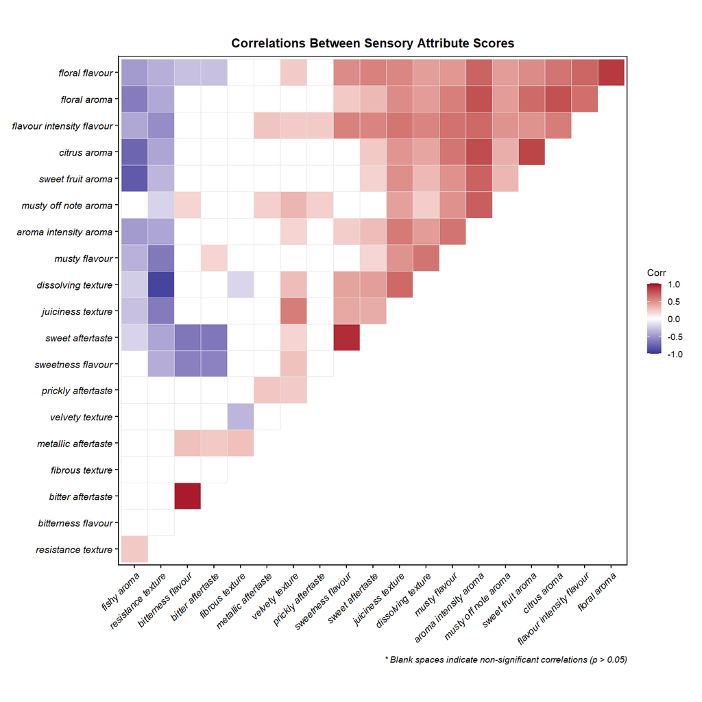

```r
# Data preparation
sens_vars <- full_data_matrix |>
  select(ID, aroma_intensity_AR:prickly_AT) |>
  pivot_longer(aroma_intensity_AR:prickly_AT, names_to = "var", values_to = "score") |>
  left_join(sensory_meta) |>
  select(ID, label2, score) |>
  pivot_wider(names_from = "label2", values_from = "score") |>
  select(-ID)

# Calculate the correlation matrix
corr <- cor(sens_vars)

# Calculate p-values
p_mat <- cor_pmat(sens_vars) |>
  select(-rowname) |>
  as.matrix()

ggcorrplot(
  corr,
  method = "square",
  type = "upper",
  hc.order = TRUE,
  hc.method = "complete",
  colors = c("#313695", "white", "#A50026"),
  p.mat = p_mat,
  sig.level = 0.05,
  insig = "blank",
  # lab = TRUE,
  # lab_size = 2.8,
  tl.cex = 7,
  tl.srt = 45,
  digits = 2,
  ggtheme = ggplot2::theme_classic(),
  outline.color = "gray90"
) +
  theme(
    # Text elements
    axis.text.x = element_text(angle = 45,
                               hjust = 1,
                               face = "italic",
                               size = 8),
    axis.text.y = element_text(face = "italic",
                               size = 8),
    axis.title = element_blank(),

    # Panel elements
    panel.grid = element_blank(),
    panel.border = element_rect(color = "black",
                                fill = NA,
                                linewidth = 0.5),
    # Legend customization
    legend.position = "right",
    legend.title = element_text(size = 8),
    legend.text = element_text(size = 7),
    legend.key.size = unit(0.8, "lines"),

    # Title and caption
    plot.title = element_text(size = 10,
                              face = "bold",
                              hjust = 0.5),
    plot.caption = element_text(size = 7,
                                hjust = 1,
                                face = "italic"),

    # Margins
    plot.margin = margin(10, 10, 10, 10)
  ) +
  labs(
    title = "Correlations Between Sensory Attribute Scores",
    caption = "* Blank spaces indicate non-significant correlations (p > 0.05)"
  )
```

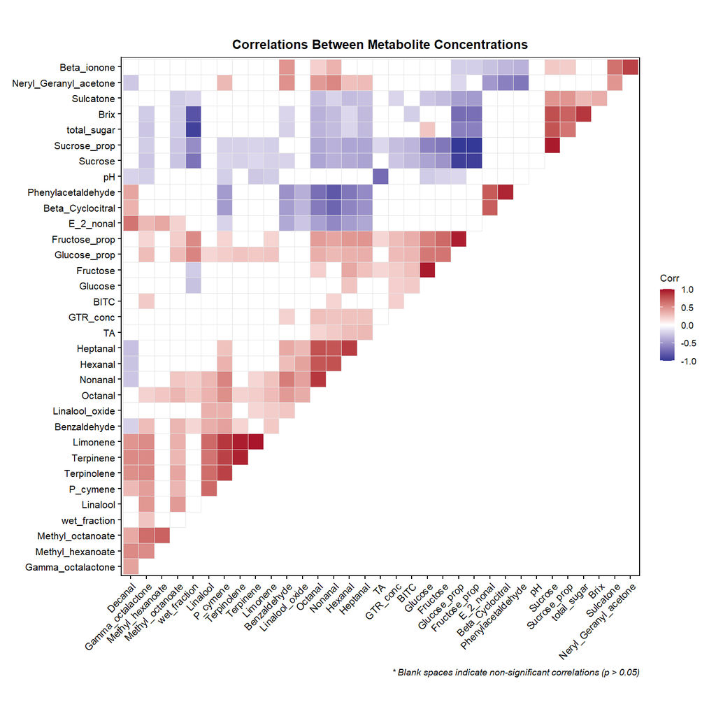

```r
# Data preparation
mets_vars <- full_data_matrix |>
  select(where(is.numeric)) |>
  select(Glucose:BITC)

# Calculate the correlation matrix
corr2 <- cor(mets_vars)

# Calculate p-values
p_mat2 <- cor_pmat(mets_vars) |>
  select(-rowname) |>
  as.matrix()

ggcorrplot(
  corr2,
  method = "square",
  type = "upper",
  hc.order = TRUE,
  hc.method = "complete",
  colors = c("#313695", "white", "#A50026"),
  p.mat = p_mat2,
  sig.level = 0.05,
  insig = "blank",
  # lab = TRUE,
  # lab_size = 2.8,
  tl.cex = 7,
  tl.srt = 45,
  digits = 2,
  ggtheme = ggplot2::theme_classic(),
  outline.color = "gray90"
) +
  theme(
    # Text elements
    axis.text.x = element_text(angle = 45,
                               hjust = 1,
                               size = 8),
    axis.text.y = element_text(size = 8),
    axis.title = element_blank(),

    # Panel elements
    panel.grid = element_blank(),
    panel.border = element_rect(color = "black",
                                fill = NA,
                                linewidth = 0.5),
    # Legend customization
    legend.position = "right",
    legend.title = element_text(size = 8),
    legend.text = element_text(size = 7),
    legend.key.size = unit(0.8, "lines"),

    # Title and caption
    plot.title = element_text(size = 10,
                              face = "bold",
                              hjust = 0.5),
    plot.caption = element_text(size = 7,
                                hjust = 1,
                                face = "italic"),

    # Margins
    plot.margin = margin(10, 10, 10, 10)
  ) +
  labs(
    title = "Correlations Between Metabolite Concentrations",
    caption = "* Blank spaces indicate non-significant correlations (p > 0.05)"
  )
```

```r
# ggsave("mets_corr.png",
#        width = 8,
#        height = 7,
#        dpi = 600,
#        bg = "white",
#        units = "in")
```

## 6 Sensory and metabolite Principal Component Analysis

Metabolites with odour activity values less than one likely play a very minor role in fruit flavour; due to the small ranges and fluctuations, their influence on flavour may be overestimated in modelling. Moreover, sensory terms including prickly aftertaste and metallic aftertaste poorly differentiated the genotypes throughout descriptive analysis. Therefore these variables were removed to focus on highly relevant flavour variables.

```r
# cut VOC variables
no_aroma <- VOCs %>%
  select(1:6,OAV) %>%
  pivot_wider(names_from = species, values_from = OAV) %>%
  select(Hexanal:BITC) %>%
  summarise(across(where(is.numeric), ~ max(.x, na.rm = TRUE))) %>%
  select(where(function(x) any(x<1))) %>%
  colnames()

# cut sensory variables
poor_lexicon_use <- c("prickly_AT", "metallic_AT")
```

Once these variables were removed the data was visualised using PCA to look at sensory and metabolite profiles of each genotype.

```r
# data set up
remove_vars <- c("Glucose_prop","Fructose_prop","Sucrose_prop","label","Genotype2")
PCA_data <- full_data_matrix %>%
  column_to_rownames(var = "ID") %>%
  select(-all_of(c(poor_lexicon_use, no_aroma,remove_vars,"Beta_Cyclocitral")))
# Beta_Cyclocitral appears to have very low range and is exacerbating small differences due to presence absence

# PCA script custom bi-plot
PCA_vocs <- PCA(PCA_data, scale.unit = TRUE,
                ncp = 5, graph = F,
                quali.sup = 1:31) # omit all but sensory columns

# make a list of top variables based on visual assessment
topvars <- PCA_vocs$var$contrib [,1:2] %>% as.data.frame() %>%
  rownames_to_column(var = "species") %>% mutate (contribution = Dim.1 + Dim.2) %>%
  top_n(17, contribution)

# make a dataframe with variable coordinates for arrows
PCAvar_coords <- PCA_vocs$var$coord[topvars$species,] %>%
  as.data.frame() %>%
  select(1:2) %>%
  rownames_to_column(var = "var") %>%
  left_join(sensory_meta) %>%
  mutate(Category = snakecase::to_title_case(group),
         sensory_label = snakecase::to_sentence_case(sub("_[A-Z]+$", "", var)),
         label = tolower(label))

# create a scale value to the size of the scatter plot to adjust variable coordinates
var <- facto_summarize(PCA_vocs,
                       element = "var",
                       result = c("coord", "contrib", "cos2"))

colnames(var)[2:3] <- c("x", "y")

ind <- data.frame(PCA_vocs$ind$coord[, drop = FALSE],
                  stringsAsFactors = TRUE)

colnames(ind) <- c("x", "y")

r <- min((max(ind[, "x"]) - min(ind[, "x"])/(max(var[, "x"]) - min(var[, "x"]))),
         (max(ind[, "y"]) - min(ind[, "y"])/(max(var[,"y"]) - min(var[, "y"]))))

# update the variable coordinates

PCAvar_plot_data <- PCAvar_coords %>%
                    as_tibble() %>%
                    mutate(across(starts_with("Dim"), ~r*0.6*.x)) # this number scales arrow length

# get coordinates for individuals to map group means with meta data for aesthetics
PCAvoctable <- PCA_vocs$ind$coord %>%
               as.data.frame() %>%
               rownames_to_column("ID") %>%
               left_join(genotype_table)

# create a table with the average coordinates for each phenotype
Mean_coords <- PCAvoctable %>%
               group_by(label) %>%
               summarise(across(where(is.numeric), ~mean(.x, na.rm = TRUE))) %>%
               left_join(genotype_table %>% distinct(label,Flesh, Genotype, Genotype2, assay))


# choose colours
my_colours <- c("#E31A1C","gold2")


# Get component variance information for axis labels
percentVar <- PCA_vocs$eig[1:2,2]

#plot PCA coords using ggplot

ggplot(Mean_coords) +
  aes(x = Dim.1, y = Dim.2, fill = Flesh, shape = assay) +
  geom_hline(yintercept = 0, alpha = 0.6,
             linetype="dashed", linewidth=0.5) +
  geom_vline(xintercept = 0, alpha = 0.6,
             linetype="dashed", linewidth=0.5) +
  geom_segment(mapping = aes(colour=group, xend=Dim.1, yend=Dim.2),
               data = PCAvar_plot_data,
               inherit.aes = F,
               x=0, y=0, linewidth=0.3,
               arrow = arrow(angle = 30, length = unit(0.2, "cm"))) +
  geom_text_repel(mapping = aes(colour=group, x=Dim.1, y=Dim.2, label=label),
                  data = PCAvar_plot_data,
                  inherit.aes = F,
                  fontface = "italic",
                  hjust=-0.15, vjust=0.20, size=3.2, box.padding = 0.1) +
  scale_color_manual(values = c("#8B0000", "#000080", "#228B22", "#708090")) +
  geom_point(alpha = 1, size=2.5) +
  theme_bw() + theme(plot.background = element_blank(),
                     panel.grid.major = element_blank(),
                     panel.grid.minor = element_blank(),
                     axis.title = element_text(size=12)) +
  geom_text_repel(label = Mean_coords$Genotype2,
                  size=3, hjust=-0.2, vjust=0.5, box.padding = 0.2,
                  colour = "black") +
   scale_shape_manual(values = c(21,22,24)) +scale_fill_manual(values = my_colours) +
  guides(colour=guide_legend(override.aes = list(label="")))+
  scale_fill_identity(guide = guide_legend(override.aes = list(shape = 21))) +
  labs( x=glue::glue("C1: {round(percentVar[1],2)}% variance"),
        y=glue::glue("C2: {round(percentVar[2],2)}% variance"), fill="Flesh",
        colour="Attribute", shape = "Havest Month")
```

[figure not shown]

Figure 3: PCA biplot of 27 papaya genotype dipicting the variations in sensory profiles from quantitative descriptive analysis.

```r
PCA_vocs <- PCA(PCA_data, scale.unit = TRUE,
                ncp = 6, graph = F,
                quali.sup = c(1:3,31:48)) # all chem PCA

# make a list of top variables based on visual assessment
topvars <- PCA_vocs$var$contrib[,1:2] %>% as.data.frame() %>%
  rownames_to_column(var = "species") %>% mutate (contribution = Dim.1 + Dim.2) %>%
  top_n(22, contribution)

# make a dataframe with variable coordinates for arrows
PCAvar_coords <- PCA_vocs$var$coord[topvars$species,] %>%
  as.data.frame() %>%
  select(1:2) %>%
  rownames_to_column(var = "var") %>%
  left_join(class_key, by = "var") %>%
  mutate(var=str_replace_all(var, c("Neryl_Geranyl_acetone" = "Neryl/Geranyl Acetone", "E_2_nonal"="E-2-Nonanal","P_cymene"="P-Cymene","_"=" ")), group=str_replace_all(group, c("Acids"="Sugar/acid","Sugars"="Sugar/acid")))

# create a scale value to the size of the scatter plot to adjust variable coordinates
var <- facto_summarize(PCA_vocs,
                       element = "var",
                       result = c("coord", "contrib", "cos2"))

colnames(var)[2:3] <- c("x", "y")

ind <- data.frame(PCA_vocs$ind$coord[, drop = FALSE],
                  stringsAsFactors = TRUE)

colnames(ind) <- c("x", "y")

r <- min((max(ind[, "x"]) - min(ind[, "x"])/(max(var[, "x"]) - min(var[, "x"]))),
         (max(ind[, "y"]) - min(ind[, "y"])/(max(var[,"y"]) - min(var[, "y"]))))

# update the variable coordinates

PCAvar_plot_data <- PCAvar_coords %>%
  as_tibble() %>%
  mutate(across(starts_with("Dim"), ~r*0.6*.x))

# get coordinates for individuals to map group means with meta data for aesthetics
PCAvoctable <- PCA_vocs$ind$coord %>%
  as.data.frame() %>%
  rownames_to_column("ID") %>%
  left_join(genotype_table)

# create a table with the average coordinates for each phenotype
Mean_coords <- PCAvoctable %>%
  group_by(label,Flesh) %>%
  summarise(across(where(is.numeric), ~mean(.x, na.rm = TRUE))) %>%
  left_join(genotype_table %>% distinct(label, Flesh, Genotype, Genotype2,assay))

# choose colours
my_colours <- c("#E31A1C","gold2")


# Get component variance information for axis labels
percentVar <- PCA_vocs$eig[1:2,2]

#plot PCA coords using ggplot

ggplot(Mean_coords) +
  aes(x = Dim.1, y = Dim.2, fill = Flesh, shape = assay) +
  geom_hline(yintercept = 0, alpha = 0.6,
             linetype="dashed", linewidth=0.5) +
  geom_vline(xintercept = 0, alpha = 0.6,
             linetype="dashed", linewidth=0.5) +
  geom_segment(mapping = aes(colour=group, xend=Dim.1, yend=Dim.2),
               data = PCAvar_plot_data,
               inherit.aes = F,
               x=0, y=0, linewidth=0.3,
               arrow = arrow(angle = 30, length = unit(0.2, "cm"))) +
  geom_text_repel(mapping = aes(colour=group, x=Dim.1, y=Dim.2, label=label),
                  data = PCAvar_plot_data,
                  fontface = "italic",
                  inherit.aes = F,
                  hjust=0.3, vjust=-0.6, size=3.2, box.padding = 0.1) +
  scale_color_manual(values = c("#8B0000", "#000080", "#228B22", "#708090","darkorange")) +
  geom_point(alpha = 1, size=2.5) +
  theme_bw() + theme(plot.background = element_blank(),
                     panel.grid.major = element_blank(),
                     panel.grid.minor = element_blank(),
                     axis.title = element_text(size=12)) +
  geom_text_repel(label = Mean_coords$Genotype2,
                  size=3, hjust=1.1, vjust=1.2, box.padding = 0.1,
                  colour = "black") +
  scale_shape_manual(values = c(21,22,24)) +scale_fill_manual(values = my_colours) +
  guides(colour=guide_legend(override.aes = list(label="")))+
  scale_fill_identity(guide = guide_legend(override.aes = list(shape = 21))) +
  labs( x=glue::glue("C1: {round(percentVar[1],2)}% variance"),
        y=glue::glue("C2: {round(percentVar[2],2)}% variance"), fill="Flesh",
        colour="Attribute", shape = "Havest Month")
```

[figure not shown]

Figure 4: CA biplot of 27 papaya genotype dipicting the variations in metabolite profiles from targeted quantitative chemical assays. Including metabolites with concentrations theorectically above an odour threshold of one in one or more genotype.

There appears to be a significant batch effect associated with metabolites with highly skewed distributions. After removing decanal, methyl hexanoate, octanal, (E)-2-nonanal and nonanal, the control genotypes are qualitatively similar in distance to what is observed in the sensory data.

```r
PCA_vocs <- PCA(PCA_data, scale.unit = TRUE,
                ncp = 6, graph = F,
                quali.sup = c(1:3,21,23:26,31:48)) # omit decanal, methyl hexanoate, octanal, (E)-2-nonanal, nonanal

# make a list of top variables based on visual assessment
topvars <- PCA_vocs$var$contrib [,1:2] %>% as.data.frame() %>%
  rownames_to_column(var = "species") %>% mutate (contribution = Dim.1 + Dim.2) %>%
  top_n(22, contribution)
# make a dataframe with variable coordinates for arrows
PCAvar_coords <- PCA_vocs$var$coord[topvars$species,] %>%
  as.data.frame() %>%
  select(1:2) %>%
  rownames_to_column(var = "var") %>%
  left_join(class_key) %>%
  mutate(var=str_replace_all(var, c("Neryl_Geranyl_acetone" = "Neryl/Geranyl Acetone", "E_2_nonal"="E-2-Nonanal","P_cymene"="P-Cymene","_"=" ")), group=str_replace_all(group, c("Acids"="Sugar/acid","Sugars"="Sugar/acid")))

# create a scale value to the size of the scatter plot to adjust variable coordinates
var <- facto_summarize(PCA_vocs,
                       element = "var",
                       result = c("coord", "contrib", "cos2"))

colnames(var)[2:3] <- c("x", "y")

ind <- data.frame(PCA_vocs$ind$coord[, drop = FALSE],
                  stringsAsFactors = TRUE)

colnames(ind) <- c("x", "y")

r <- min((max(ind[, "x"]) - min(ind[, "x"])/(max(var[, "x"]) - min(var[, "x"]))),
         (max(ind[, "y"]) - min(ind[, "y"])/(max(var[,"y"]) - min(var[, "y"]))))

# update the variable coordinates

PCAvar_plot_data <- PCAvar_coords %>%
  as_tibble() %>%
  mutate(across(starts_with("Dim"), ~r*0.6*.x))

# get coordinates for individuals to map group means with meta data for aesthetics
PCAvoctable <- PCA_vocs$ind$coord %>%
  as.data.frame() %>%
  rownames_to_column("ID") %>%
  left_join(genotype_table)

# create a table with the average coordinates for each phenotype
Mean_coords <- PCAvoctable %>%
  group_by(label,Flesh) %>%
  summarise(across(where(is.numeric), ~mean(.x, na.rm = TRUE))) %>%
  left_join(genotype_table %>% distinct(label, Flesh, Genotype, Genotype2,assay))

# choose colours
my_colours <- c("#E31A1C","gold2")


# Get component variance information for axis labels
percentVar <- PCA_vocs$eig[1:2,2]

#plot PCA coords using ggplot

ggplot(Mean_coords) +
  aes(x = Dim.1, y = Dim.2, fill = Flesh, shape = assay) +
  geom_hline(yintercept = 0, alpha = 0.6,
             linetype="dashed", linewidth=0.5) +
  geom_vline(xintercept = 0, alpha = 0.6,
             linetype="dashed", linewidth=0.5) +
  geom_segment(mapping = aes(colour=group, xend=Dim.1, yend=Dim.2),
               data = PCAvar_plot_data,
               inherit.aes = F,
               x=0, y=0, linewidth=0.3,
               arrow = arrow(angle = 30, length = unit(0.2, "cm"))) +
  geom_text_repel(mapping = aes(colour=group, x=Dim.1, y=Dim.2, label=label),
                  data = PCAvar_plot_data,
                  inherit.aes = F,
                  fontface = "italic",
                  hjust=0.3, vjust=-0.6, size=3.2, box.padding = 0.1) +
  scale_color_manual(values = c("#8B0000", "#000080", "#228B22", "#708090","darkorange")) +
  geom_point(alpha = 1, size=2.5) +
  theme_bw() + theme(plot.background = element_blank(),
                     panel.grid.major = element_blank(),
                     panel.grid.minor = element_blank(),
                     axis.title = element_text(size=12)) +
  geom_text_repel(label = Mean_coords$Genotype2,
                  size=3, hjust=1.1, vjust=1.2, box.padding = 0.1,
                  colour = "black") +
  scale_shape_manual(values = c(21,22,24)) +scale_fill_manual(values = my_colours) +
  guides(colour=guide_legend(override.aes = list(label="")))+
  scale_fill_identity(guide = guide_legend(override.aes = list(shape = 21))) +
  scale_x_continuous(limits = c(-3,3.5))+
  labs( x=glue::glue("C1: {round(percentVar[1],2)}% variance"),
        y=glue::glue("C2: {round(percentVar[2],2)}% variance"), fill="Flesh",
        colour="Attribute", shape = "Havest Month")
```

[figure not shown]

Figure 5: PCA biplot of 27 papaya genotype dipicting the variations in metabolite profiles from targeted quantitative chemical assays. Including metabolites with concentrations theorectically above an odour threshold of one in one or more genotype. Excluding decanal, methyl hexanoate, octanal, (E)-2-nonanal and nonanal.

## 7 Modelling the interactions between sensory and metabolite profiles

Variable influences on traits were assessed using two complementary approaches: (1) generalised boosted regression (Friedman 2001) to capture both main effects and interactions (x-axis), optimized using 10-fold cross-validation, and (2) Bayesian linear regression (BayesA; Meuwissen *et al.* (2001)) to estimate individual additive effects without interactions (y-axis). Only variables that stood out from the rest were labelled due to space limitations.

```r
scaled_matrix <- PCA_data %>% select(-c(1:3,21,23:26)) %>% scale()

# Sensory subsetting
# column naming
traits <- colnames(scaled_matrix) [23:40]
gbm_name <- c(seq(from = 1, to = 35, by = 2))
beta_name <- c(seq(from = 2, to = 36, by = 2))

set.seed(11)

for (i in 1:18) {

  # caret GBM
  carX <- as.matrix(cbind(Y=scaled_matrix[,22+i], scaled_matrix[,1:22]))

  grid <- expand.grid(.n.trees = c(500, 750, 1000),
                      .interaction.depth = c(5,7,10),
                      .shrinkage = c(0.01,0.02,0.05),
                      .n.minobsinnode = c(3,5))

  trnCtrl <- trainControl(method = "cv", number = 10)

  gbm <- train(Y ~ ., data = carX, method = "gbm", trControl = trnCtrl, tuneGrid = grid)

  # BGLR
  trnY <- scaled_matrix[,22+i]

  ETA <- list(list(X = scaled_matrix[,1:22], model = 'BayesA'))

  fit_BA <- BGLR::BGLR(y = trnY,
                 ETA = ETA,
                 nIter = 30000,
                 burnIn = 10000,
                 thin = 100,
                 saveAt = 'data/',
                 df0 = 5,
                 S0 = NULL,
                 weights = NULL,
                 R2 = 0.5)

 # write results table
  if(i == 1){
    wts <- as.data.frame(varImp(object = gbm)$importance) %>%
           cbind(fit_BA$ETA[[1]]$b)
    names(wts)[i] <- paste0(traits[i],"_gbm")
    names(wts)[i+1] <- paste0(traits[i],"_beta")
  } else {
    wts <- cbind(wts,varImp(object = gbm)$importance,fit_BA$ETA[[1]]$b)
    names(wts)[gbm_name[i]] <- paste0(traits[i],"_gbm")
    names(wts)[beta_name[i]] <- paste0(traits[i],"_beta")
  }
}

save(wts,traits,beta_name, gbm_name,  file = "data/sensory_modelling.RData")
```

```r
# Plot prep ------------
bglr_data <- wts %>%
  select(all_of(beta_name)) %>%
  rownames_to_column(var = "var") %>%
  left_join(class_key) %>%
  pivot_longer(cols = 2:19, values_to = "y", names_to = "trait") %>%
  mutate(trait=str_replace_all(trait,"_beta",""))

gbm_data <- wts %>%
  select(all_of(gbm_name)) %>%
  rownames_to_column(var = "var") %>%
  left_join(class_key) %>%
  select(-label2) |>
  pivot_longer(cols = 2:19, values_to = "x", names_to = "trait") %>%
  mutate(trait=str_replace_all(trait,"_gbm",""))

all_plot_data <- left_join(bglr_data,gbm_data[c(1,4:5)],by=c("var" = "var", "trait" = "trait")) %>%
                mutate(sensory_group = str_sub(trait, - 2, - 1),
                       trait_label = str_sub(trait,0,-4),
                       trait_label = str_replace_all(trait_label,"_"," "),
                       trait_label = str_to_sentence(trait_label),
                       label = str_replace_all(label,c("total sugar"="Total sugar",
                                                       "wet fraction"="Water content")))
# Filter for AR labels -------
ar_label <-
  rbind(
    all_plot_data %>% filter(sensory_group == "AR") %>%
      group_by(trait) %>% slice_min(y, n=4),

    all_plot_data %>%  filter(sensory_group == "AR") %>%
      group_by(trait) %>% slice_max(y, n=4),

    all_plot_data %>% filter(sensory_group == "AR") %>%
      group_by(trait) %>% slice_max(x, n=8)) %>%

  distinct()

my_colours <- c("#1f77b4", "#ff7f0e", "#2ca02c", "#d62728", "#9467bd",
                  "#8c564b", "#e377c2", "#7f7f7f", "#bcbd22")

# Need labels to remove
# Determined by initially plotting AR_label

AR_intensity <- c("Terpinolene","Heptanal","Terpinene","(E/Z)-Geranylacetone","Sucrose",
                  "Hexanal")
AR_citrus <- c("Glucose","Hexanal","Limonene","Sucrose","Heptanal","Sulcatone","β-Ionone","Terpinene")
AR_fishy <- c("Sucrose","Glucose","P-Cymene","pH","β-Ionone","Sulcatone","TA")
AR_floral <- c("(E/Z)-Geranylacetone","β-Ionone", "Hexanal","Sulcatone","(E/Z)-Geranylacetone")
AR_musty <- c("Linalool oxide", "Terpinolene", "GTR","(E/Z)-Geranylacetone")
AR_sweet <- c("BITC","β-Ionone","Linalool oxide","P-Cymene","Hexanal","GTR","pH","Total sugar")

# Filter labels and plot

ar_label1 <- ar_label %>%
  filter(!label %in% AR_intensity & trait=="aroma_intensity_AR"|
         !label %in% AR_citrus & trait == "citrus_AR" |
         !label %in% AR_fishy & trait == "fishy_AR"|
         !label %in% AR_floral & trait == "floral_AR"|
         !label %in% AR_musty & trait == "musty_off_note_AR"|
         !label %in% AR_sweet & trait == "sweet_fruit_AR")


#plot AROMA trait variables
ggplot(all_plot_data %>% filter(sensory_group == "AR")) +
  aes(x = x, y = y,
      fill = group,
      colour = group,
      label = label) +

  # Base plot elements
  geom_hline(yintercept = 0,
             alpha = 0.6,
             linetype = "dashed",
             linewidth = 0.5) +
  geom_point(shape = 21,
             alpha = 0.7,
             size = 2.5) +

  # Faceting and coordinates
  facet_wrap(vars(trait_label)) +
  xlim(0, 100) +
  ylim(min(all_plot_data[all_plot_data$sensory_group=="AR",] %>% select(y)),
       max(all_plot_data[all_plot_data$sensory_group=="AR",] %>% select(y))) +


  # Labels
  labs(x = "Variable importance (GBM)",
       y = expression(beta~"coefficient (BayesA)"),
       fill = "") +

  # Point labels
  geom_text_repel(data = ar_label1,
                  aes(x = x, y = y,
                      label = label,
                      color = group),
                  hjust = -.1,
                  vjust = -0.4,
                  size = 3,
                  box.padding = 0.1) +

  # Colours and guides
  scale_fill_manual(breaks = c("Carotenoid/Terpenes", "Lipid-derived",
                              "Phenylalanine-derived", "Sugars",
                              "Acids", "Other"),
                   values = my_colours) +
  scale_color_manual(breaks = c("Carotenoid/Terpenes", "Lipid-derived",
                               "Phenylalanine-derived", "Sugars",
                               "Acids", "Other"),
                    values = my_colours) +
  guides(colour = "none") +

  # Theme customisation
  theme_bw() +
  theme(
    plot.background = element_blank(),
    panel.background = element_blank(),
    panel.border = element_rect(linetype = "solid", colour = "Black"),
    panel.grid.major = element_blank(),
    panel.grid.minor = element_blank(),
    axis.title = element_text(size = 11),
    axis.title.x = element_text(vjust = -2),
    axis.title.y = element_text(vjust = 2),
    axis.text = element_text(size = 8),
    legend.background = element_blank(),
    strip.background = element_blank(),
    strip.text = element_text(size = 11, face = "bold"),
    panel.spacing.y = unit(0, "cm", data = NULL),
    legend.position = "bottom"
  )
```

[figure not shown]

Figure 6: Variation in papaya aroma characteristics explained by targeted metabolites in 27 papaya genotypes.

```r
# Filter for FL labels -------
FL_label <-
  rbind(
    all_plot_data %>% filter(sensory_group == "FL") %>%
      group_by(trait) %>% slice_min(y, n=5),
    all_plot_data %>% filter(sensory_group == "FL") %>%
      group_by(trait) %>% slice_max(y, n=5),
    all_plot_data %>% filter(sensory_group == "FL") %>%
      group_by(trait) %>% slice_max(x, n=8)) %>%
  distinct()

my_colours <- c("#1f77b4", "#ff7f0e", "#2ca02c", "#d62728", "#9467bd",
                "#8c564b", "#e377c2", "#7f7f7f", "#bcbd22")

# Need labels to remove
# Determined by initially plotting FL_label

FL_bitterness <- c("γ-Octalactone", "Sucrose","Hexanal","Glucose","Terpinolene","Water fraction","Brix")
FL_intensity <- c("Sulcatone", "β-Ionone","Linalool","TA","BITC")
FL_floral <- c("Brix","Linalool oxide","(E/Z)-Geranylacetone","Terpinene")
FL_musty <- c("Terpinene","Sulcatone")
FL_sweet <- c("Fructose","Linalool oxide","Glucose","GTR", "TA","pH","γ-Octalactone")

# Filter labels and plot

FL_label1 <- FL_label %>%
  filter(!label %in% FL_bitterness & trait=="bitterness_FL"|
           !label %in% FL_intensity & trait == "flavour_intensity_FL" |
           !label %in% FL_floral & trait == "floral_FL"|
           !label %in% FL_musty & trait == "musty_FL"|
           !label %in% FL_sweet & trait == "sweetness_FL")


# Plot flavour trait variables
ggplot(all_plot_data %>% filter(sensory_group == "FL")) +
  aes(x = x, y = y,
      fill = group,
      colour = group,
      label = label) +

  # Base plot elements
  geom_hline(yintercept = 0,
             alpha = 0.6,
             linetype = "dashed",
             linewidth = 0.5) +
  geom_point(shape = 21,
             alpha = 0.7,
             size = 2.5) +

  # Faceting and coordinates
  facet_wrap(vars(trait_label)) +
  xlim(0, 100) +
  ylim(min(all_plot_data %>% filter(sensory_group == "FL") %>% select(y)),
       max(all_plot_data %>% filter(sensory_group == "FL") %>% select(y))) +

  # Labels
  labs(x = "Variable importance (GBM)",
       y = expression(beta~"coefficient (BayesA)"),
       fill = "") +

  # Point labels
  geom_text_repel(data = FL_label1,
                  aes(x = x, y = y,
                      label = label,
                      color = group),
                  hjust = -0,
                  vjust = -0.5,
                  size = 3,
                  box.padding = 0.1) +

  # Colours and guides
  scale_fill_manual(breaks = c("Carotenoid/Terpenes", "Lipid-derived",
                              "Phenylalanine-derived", "Sugars",
                              "Acids", "Other"),
                   values = my_colours) +
  scale_color_manual(breaks = c("Carotenoid/Terpenes", "Lipid-derived",
                               "Phenylalanine-derived", "Sugars",
                               "Acids", "Other"),
                    values = my_colours) +
  guides(colour = "none") +

  # Theme customisation
  theme_bw() +
  theme(
    plot.background = element_blank(),
    panel.background = element_blank(),
    panel.border = element_rect(linetype = "solid", colour = "Black"),
    panel.grid.major = element_blank(),
    panel.grid.minor = element_blank(),
    axis.title = element_text(size = 11),
    axis.title.x = element_text(vjust = -2),
    axis.title.y = element_text(vjust = 2),
    axis.text = element_text(size = 8),
    legend.background = element_blank(),
    strip.background = element_blank(),
    strip.text = element_text(size = 11, face = "bold"),
    panel.spacing.y = unit(0, "cm", data = NULL),
    legend.position = "bottom"
  )
```

[figure not shown]

```r
# First filter for AT labels -------
AT_label <-
  rbind(
    all_plot_data %>% filter(sensory_group == "AT") %>%
      group_by(trait) %>% slice_min(y, n=4),
    all_plot_data %>% filter(sensory_group == "AT") %>%
      group_by(trait) %>% slice_max(y, n=2),
    all_plot_data %>% filter(sensory_group == "AT") %>%
      group_by(trait) %>% slice_max(x, n=7)) %>%
  distinct()

my_colours <- c("#1f77b4", "#ff7f0e", "#2ca02c", "#d62728", "#9467bd",
                "#8c564b", "#e377c2", "#7f7f7f", "#bcbd22")

# Plot aftertaste trait variables
ggplot(all_plot_data %>% filter(sensory_group == "AT")) +
  aes(x = x, y = y,
      fill = group,
      colour = group,
      label = label) +

  # Base plot elements
  geom_hline(yintercept = 0,
             alpha = 0.6,
             linetype = "dashed",
             linewidth = 0.5) +
  geom_point(shape = 21,
             alpha = 0.7,
             size = 2.5) +

  # Faceting and coordinates
  facet_wrap(vars(trait_label)) +
  xlim(0, 100) +
  ylim(min(all_plot_data %>% filter(sensory_group == "AT") %>% select(y)),
       max(all_plot_data %>% filter(sensory_group == "AT") %>% select(y))) +

  # Labels
  labs(x = "Variable importance (GBM)",
       y = expression(beta~"coefficient (BayesA)"),
       fill = "") +

  # Point labels
  geom_text_repel(data = AT_label,
                  aes(x = x, y = y,
                      label = label,
                      color = group),
                  hjust = 0,
                  vjust = 0,
                  size = 3,
                  box.padding = 0.15) +

  # Colours and guides
  scale_fill_manual(breaks = c("Carotenoid/Terpenes", "Lipid-derived",
                              "Phenylalanine-derived", "Sugars",
                              "Acids", "Other"),
                   values = my_colours) +
  scale_color_manual(breaks = c("Carotenoid/Terpenes", "Lipid-derived",
                               "Phenylalanine-derived", "Sugars",
                               "Acids", "Other"),
                    values = my_colours) +
  guides(colour = "none") +

  # Theme customisation
  theme_bw() +
  theme(
    plot.background = element_blank(),
    panel.background = element_blank(),
    panel.border = element_rect(linetype = "solid", colour = "Black"),
    panel.grid.major = element_blank(),
    panel.grid.minor = element_blank(),
    axis.title = element_text(size = 11),
    axis.title.x = element_text(vjust = -2),
    axis.title.y = element_text(vjust = 2),
    axis.text = element_text(size = 8),
    legend.background = element_blank(),
    strip.background = element_blank(),
    strip.text = element_text(size = 11, face = "bold"),
    panel.spacing.y = unit(0, "cm", data = NULL),
    legend.position = "bottom"
  )
```

[figure not shown]

Figure 8: Variation in papaya aftertaste characteristics explained by targeted metabolites in 27 papaya genotypes.

```r
#First filter for TX labels -------
  TX_label <-
  rbind(
    all_plot_data %>% filter(sensory_group == "TX") %>%
      group_by(trait) %>% slice_min(y, n=2),
    all_plot_data %>% filter(sensory_group == "TX") %>%
      group_by(trait) %>% slice_max(y, n=2),
    all_plot_data %>% filter(sensory_group == "TX") %>%
      group_by(trait) %>% slice_max(x, n=2)) %>%
  distinct()

my_colours <- c("#1f77b4", "#ff7f0e", "#2ca02c", "#d62728", "#9467bd",
                "#8c564b", "#e377c2", "#7f7f7f", "#bcbd22")

# Plot TEXTURE trait variables
ggplot(all_plot_data %>% filter(sensory_group == "TX")) +
  aes(x = x, y = y,
      fill = group,
      colour = group,
      label = label) +

  # Base plot elements
  geom_hline(yintercept = 0,
             alpha = 0.6,
             linetype = "dashed",
             linewidth = 0.5) +
  geom_point(shape = 21,
             alpha = 0.7,
             size = 2.5) +

  # Faceting and coordinates
  facet_wrap(vars(trait_label)) +
  xlim(0, 100) +
  ylim(min(all_plot_data %>% filter(sensory_group == "TX") %>% select(y)),
       max(all_plot_data %>% filter(sensory_group == "TX") %>% select(y))) +

  # Labels
  labs(x = "Variable importance (GBM)",
       y = expression(beta~"coefficient (BayesA)"),
       fill = "") +

  # Point labels
  geom_text_repel(data = TX_label,
                  aes(x = x, y = y,
                      label = label,
                      color = group),
                  hjust = 0,
                  vjust = 0,
                  size = 3,
                  box.padding = 0.15) +

  # Colours and guides
  scale_fill_manual(breaks = c("Carotenoid/Terpenes", "Lipid-derived",
                              "Phenylalanine-derived", "Sugars",
                              "Acids", "Other"),
                   values = my_colours) +
  scale_color_manual(breaks = c("Carotenoid/Terpenes", "Lipid-derived",
                               "Phenylalanine-derived", "Sugars",
                               "Acids", "Other"),
                    values = my_colours) +
  guides(colour = "none") +

  # Theme customisation
  theme_bw() +
  theme(
    plot.background = element_blank(),
    panel.background = element_blank(),
    panel.border = element_rect(linetype = "solid", colour = "Black"),
    panel.grid.major = element_blank(),
    panel.grid.minor = element_blank(),
    axis.title = element_text(size = 11),
    axis.title.x = element_text(vjust = -2),
    axis.title.y = element_text(vjust = 2),
    axis.text = element_text(size = 8),
    legend.background = element_blank(),
    strip.background = element_blank(),
    strip.text = element_text(size = 11, face = "bold"),
    panel.spacing.y = unit(0, "cm", data = NULL),
    legend.position = "bottom"
  )
```

[figure not shown]

Figure 9: Variation in papaya texture characteristics explained by targeted metabolites in 27 papaya genotypes.

## 8 Modelling consumer liking

### 8.1 Consumer Meta Data

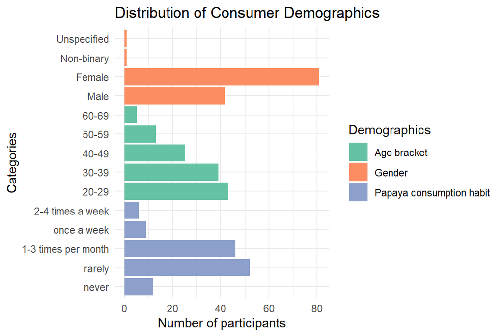

Figure 10: Consumer demographic information including distribution of ages, gender and papaya consumption habit

```r
consumer_data <- read_xlsx("data/consumer_data.xlsx")

# add age brackets for plotting
consumer_meta <- consumer_data %>%
  mutate(age_brackets = age_groups(age, split_at = "tens")) %>%
  select(-(var:dislike_text)) %>% distinct()

# pie charts
consumer_long <- consumer_meta %>%
  select(Gender, habit, age_brackets) %>%
  pivot_longer(everything(), names_to = "variable", values_to = "value")

# bar plots
consumer_long %>%
  ggplot(aes(x = value, fill = variable)) +
  geom_bar(position = "dodge") +
  coord_flip() +
  theme_minimal() +
  labs(title = "Distribution of Consumer Demographics",
       x = "Categories",
       y = "Number of participants") +
  scale_fill_brewer(palette = "Set2",
                    name = "Demographics",
                    labels = c(
                      "Gender" = "Gender",
                      "age_brackets" = "Age bracket",
                      "habit" = "Papaya consumption habit"
                    )) +
  scale_x_discrete(
    limits = c(
      # Shopping habits
      "never",
      "rarely",
      "1-3 times per month",
      "once a week",
      "2-4 times a week",
      # Age brackets
      "20-29",
      "30-39",
      "40-49",
      "50-59",
      "60-69",
      # Gender categories
      "Male",
      "Female",
      "Non-binary",
      "Unspecified"
    )
  )
```

### 8.2 Cluster analysis

Trends within the individual consumer liking scores for each genotype were identified using the affinity propagation clustering algorithm (Frey and Dueck 2007). The grouping of individual consumers into three distinct clusters reveals the interaction between their regular papaya consumption habit and how they scored each genotype during tasting. Moreover, there are indications that multiple genotypes maybe be accepted into the Australian market by different clusters of consumers.

```r
z <- consumer_data %>%
  select(participant,liking,var) %>%
  pivot_wider(names_from = var,
              values_from = liking)

# to plot the eps values
set.seed(11)
a = apcluster(negDistMat(r=2), x=z, q=0)

# # cluster exemplars
# clusters_eg <- a@exemplars %>% unname()
# kableExtra::kbl(consumer_data[clusters_eg,],
#       col.names = c("Participant", "Genotype", "Flesh Colour","Liking Score","Like Comment","Dislike Comment","Gender","Age","Consumption Habit"),
#       caption = "Cluster exemplars generated using apcluster")

# consumer clusters
c1 <- a@clusters[[1]]%>% unname()
c2 <- a@clusters[[2]]%>% unname()
c3 <- a@clusters[[3]]%>% unname()

consumer_clusters <- z %>% mutate(Cluster = c(1:125))
consumer_clusters$Cluster <- as.character(car::recode(consumer_clusters$Cluster,"c1='1';c2='2';c3='3'"))

# attach cluster membership to consumer data
cluster_data <-
  left_join(consumer_clusters,
            consumer_data %>% select(participant,Gender,age,habit) %>% distinct()) %>%
  relocate(Cluster:habit, .before = RB1) %>%
  select(-participant)

# Summarise cluster demographic data using fisher test and kruskal
cluster_membership <- cluster_data %>% select(1:4)

tab1 <- CreateTableOne(
  vars = c("Gender", "age", "habit"),
  strata = "Cluster",
  data = cluster_membership,
  factorVars = c("Gender", "habit")
)

# summarise cluster liking for each genotype

cluster_summary <- consumer_clusters %>% select(-participant) %>%
  pivot_longer(1:9,names_to = "var",values_to = "liking")

# ANOVA and Post-hoc
cluster_aov <- aov(liking ~ var * Cluster, data = cluster_summary)
cluster_ph <- SNK.test(cluster_aov, c("var","Cluster"))

# Extract data for plotting
aov_plot <-
  left_join(cluster_ph$groups %>% rownames_to_column(var="var"),
            cluster_ph$means %>% rownames_to_column(var="var")) %>%
  separate(var,
           into = c("var", "cluster"),
           sep = ":")

# second y-axis values
lam_breaks <- c(0, 13, 23, 33, 45, 50, 55, 67, 77, 87, 100)
lam_labels <- c('Greatest imaginable dislike',
                'Dislike extremely',
                'Dislike very much',
                'Dislike moderately',
                'Dislike slightly',
                'Neither like nor dislike',
                'Like slightly',
                'Like moderately',
                'Like very much',
                'like extremely',
                'Greatest imaginable like')
ggplot(aov_plot) +
aes(x = reorder(var,-liking),
    y = liking,
    group = interaction(var, cluster),
    color = cluster, fill = cluster) +
  # Add boxplot-style elements
  geom_boxplot(
    aes(ymin = Min,
        lower = Q25,
        middle = Q50,
        upper = Q75,
        ymax = Max),
    stat = "identity",
    alpha = 0.3,
    width = 0.9,
    position = position_dodge(0.9)) +
  # Add post-hoc letters
  geom_text(aes(label = groups, y = Q50 + 2),
            position = position_dodge(0.9),
            size = 2.5) +
  # Customize colors
scale_color_manual(values = c("#E69F00", "#56B4E9", "#009E73"),
                   name = 'Consumer\nCluster') +
scale_fill_manual(values = c("#E69F00", "#56B4E9", "#009E73"),
                   name = 'Consumer\nCluster',
                  labels= parse(text = c(
                    "1~(italic(n)==61)",
                    "2~(italic(n)==24)",
                    "3~(italic(n)==40)"))) +
  # remove letter in legend
  guides(color = "none") +
  # Customize theme
  theme_minimal() +
  theme(axis.text.x = element_text(angle = 45, hjust = 1),
        panel.grid.minor = element_blank(),
        panel.border = element_rect(fill = NA, color = 'black'),
        legend.position = 'bottom',
        legend.box = "horizontal",
        legend.direction = "horizontal",
        legend.margin = margin(t = 0, b = 10),
        legend.title = element_text(size = 10),
        legend.text = element_text(size = 9)) +
  # Add labels
  labs(x = 'Papaya Genotype',
       y = 'Consumer Liking Score (0-100)') +
  # Add secondary y-axis for LAM scale with no expansion
  scale_y_continuous(
    limits = c(0, 100),
    expand = c(0, 0),
    sec.axis = sec_axis(
      transform = ~.,
      breaks = lam_breaks,
      labels = lam_labels,
      name = 'Labeled Affective Magnitude (LAM) Scale'))
```

[figure not shown]

Figure 11: Consumer liking score for nine papaya genotypes recorded by 125 untrained panelists. Each panelist was grouped into a cluster based on the affinity propagation clustering algorithm. There is an interaction between geotype liking scores and cluster membership (ANOVA; p <= 0.001). The differences between genotype liking scores among all clusters are indicated by different letters (SNK: p <= 0.05).

```r
# very convoluted way to make it look good in html
tab_df <-
  as.data.frame(print(tab1)) %>%
  rownames_to_column(var = "Consumer Cluster") %>%
  gt()  %>%
  tab_caption("Breakdown of demographic data and papaya consumption habits within each consumer cluster.") %>%
  tab_footnote(
    footnote = "Kruskal wallis was applied to age and fishers test was applied to gender and papaya consumption habit.",
    locations = cells_column_labels(columns = "Consumer Cluster")
  )
```

```
>                         Stratified by Cluster
>                          1             2             3             p      test
>   n                         61            24            40
>   Gender (%)                                                        0.541
>      Female                 43 (70.5)     15 (62.5)     23 (57.5)
>      Male                   17 (27.9)      9 (37.5)     16 (40.0)
>      Non-binary              1 ( 1.6)      0 ( 0.0)      0 ( 0.0)
>      Unspecified             0 ( 0.0)      0 ( 0.0)      1 ( 2.5)
>   age (mean (SD))        36.56 (10.90) 35.92 (12.60) 36.17 (10.70)  0.968
>   habit (%)                                                         0.002
>      1-3 times per month    23 (37.7)      3 (12.5)     20 (50.0)
>      2-4 times a week        3 ( 4.9)      1 ( 4.2)      2 ( 5.0)
>      never                   2 ( 3.3)      8 (33.3)      2 ( 5.0)
>      once a week             6 ( 9.8)      1 ( 4.2)      2 ( 5.0)
>      rarely                 27 (44.3)     11 (45.8)     14 (35.0)
```

```r
# # Create flextable
# ft <- flextable(tab_df) %>%
#   theme_vanilla() %>%
#   autofit()
# Display the table
# ft
```

```r
  # PCA clusters as variables -----
pca_data <- cluster_data %>%
  pivot_longer(5:13,names_to = "var",values_to = "liking") %>%
  group_by(Cluster,var) %>%
  summarise(mean_liking = mean(liking)) %>%
  pivot_wider(names_from = "Cluster",values_from = "mean_liking") %>%
  column_to_rownames(var = "var")

plot_data <- PCA(pca_data, graph = F)
# make a dataframe with variable coordinates for arrows
PCAvar_coords <- plot_data$var$coord %>%
  as.data.frame() %>%
  select(1:2) %>%
  rownames_to_column(var = "var") %>% mutate(var=paste("Cluster",var))

# create a scale value to the size of the scatter plot to adjust variable coordinates
var <- facto_summarize(plot_data, element = "var",
                       result = c("coord", "contrib", "cos2"))
colnames(var)[2:3] <- c("x", "y")

ind <- data.frame(plot_data$ind$coord[, drop = FALSE], stringsAsFactors = TRUE)
colnames(ind) <- c("x", "y")

r <- min((max(ind[, "x"]) - min(ind[, "x"])/(max(var[, "x"]) - min(var[, "x"]))),
         (max(ind[, "y"]) - min(ind[, "y"])/(max(var[,"y"]) - min(var[, "y"]))))
# update the variable coordinates
PCAvar_plot_data <- PCAvar_coords %>% as_tibble() %>%
  mutate(across(starts_with("Dim"), ~r*0.8*.x))

# get coordinates for individuals to map group means with meta data for aesthetics
PCAvoctable <- plot_data$ind$coord %>%
  as.data.frame() %>%
  rownames_to_column("Genotype2") %>%
  left_join(genotype_table %>% select(Genotype2,Flesh) %>% distinct())

# choose colours
my_colours <- c("#E69F00", "#56B4E9", "#009E73")

# Get component variance information for axis labels
percentVar <- plot_data$eig[1:2,2]

#plot PCA coords using ggplot

ggplot(PCAvoctable) +
  aes(x = Dim.1, y = Dim.2, fill=Flesh) +
  geom_hline(yintercept = 0, alpha = 0.6,
             linetype="dashed", linewidth=0.5) +
  geom_vline(xintercept = 0, alpha = 0.6,
             linetype="dashed", linewidth=0.5) +
  geom_segment(mapping = aes(xend=Dim.1, yend=Dim.2, colour = var),
               data = PCAvar_plot_data,
               inherit.aes = F,
               x=0, y=0, linewidth=0.5,
               arrow = arrow(angle = 30, length = unit(0.2, "cm")),
               lineend = "round",linejoin = "mitre") +
  geom_text_repel(mapping = aes(x=Dim.1, y=Dim.2, label=var),
                  data = PCAvar_plot_data,
                  inherit.aes = F,
                  hjust=-0.15, vjust=-0.5, size=3.2, colour= my_colours) +
  scale_fill_manual(values = c("#E31A1C","gold2")) +
  scale_color_manual(values = c("#E69F00", "#56B4E9", "#009E73"),
                   name = 'Consumer\nCluster',
                  labels= parse(text = c(
                    "1~(italic(n)==61)",
                    "2~(italic(n)==24)",
                    "3~(italic(n)==40)"))) +
  geom_point(shape = 21,alpha = 0.9, size=2.5) +
  theme_bw() + theme(plot.background = element_blank(),
                     panel.grid.major = element_blank(),
                     panel.grid.minor = element_blank(),
                     axis.title = element_text(size=12),
                     plot.title = element_text(hjust = 0.5)) +
  geom_text_repel(label = PCAvoctable$Genotype2,
                  size=3, hjust=-0.15, vjust=-0.3,
                  colour = "black", fontface = "italic") +
  labs( x=glue::glue("C1: {round(percentVar[1],2)}% variance"),
        y=glue::glue("C2: {round(percentVar[2],2)}% variance"),
        fill="Flesh Colour",
        colour="Consumer Cluster")
```

[figure not shown]

There is an inherent limitation in the dataset whereby fruit included in the consumer study was not able to be used for chemical analysis. This is due to the logistical issues regarding adequate fruit collection and processing: the fruit that was collected was completely consumed by the panelists. To deal with this limitation best linear unbiased estimates were combined with previously collected sensory and metabolite data to represent the broad differences between genotype liking scores. This caveat likely leads to the underestimation of complex nuances between variables that influence papaya fruit liking. Therefore, the model generated from this data highlights larger variable variation between genotypes.

```r
liking_fit <- lmer(liking ~ var +
                     (1|participant),
                   data = consumer_data)

blue_df <-
  as.data.frame(
    emmeans(liking_fit,
            specs = "var")) %>%
  rename("Genotype2" = "var") %>%
  arrange(desc(emmean))

model_data <-
  left_join(PCA_data %>% rownames_to_column(var = "ID"), genotype_table) %>%
  left_join(blue_df) %>%
  filter(!is.na(emmean)) %>%
  column_to_rownames(var = "ID") %>%
  select(-c(assay:Genotype,SE:upper.CL,label:Genotype2)) %>%
  relocate(Flesh, .after = "emmean") %>%
  select(-c(Decanal,Methyl_hexanoate,Octanal,E_2_nonal, Nonanal))
#saveRDS(model_data,"model_data.RDS")
kbl(blue_df, caption = "Estimated marginal means from the mixed effects model including genotype as a fixed effect and participant as a random effect",
      col.names = c("Genotype","Least-squares mean",
                    colnames(blue_df)[3:6]),
      align = c("l",rep("c",5))) %>%
  kable_styling(bootstrap_options = c("striped", "hover")) %>%
  row_spec(0, bold = TRUE)
```

Table 6: Estimated marginal means from the mixed effects model including genotype as a fixed effect and participant as a random effect

| Genotype | Least-squares mean | SE | df | lower.CL | upper.CL |
| --- | --- | --- | --- | --- | --- |
| RB1 | 71.888 | 1.66757 | 607.539 | 68.6131 | 75.1629 |
| PBL9 | 70.368 | 1.66757 | 607.539 | 67.0931 | 73.6429 |
| PBL21 | 70.104 | 1.66757 | 607.539 | 66.8291 | 73.3789 |
| Sunlight 1 | 65.992 | 1.66757 | 607.539 | 62.7171 | 69.2669 |
| Solo | 64.888 | 1.66757 | 607.539 | 61.6131 | 68.1629 |
| PBL16 | 62.720 | 1.66757 | 607.539 | 59.4451 | 65.9949 |
| PBL14 | 56.832 | 1.66757 | 607.539 | 53.5571 | 60.1069 |
| PBL15 | 50.784 | 1.66757 | 607.539 | 47.5091 | 54.0589 |
| 1B | 39.664 | 1.66757 | 607.539 | 36.3891 | 42.9389 |

Models indicating variable influence on fruit liking can be produced from red-fleshed and yellow-fleshed data separately; however, with limited power due to sample size. Moreover, the liking scores are more accurately compared as a whole because the consumer participants tasted all samples in one sitting, as opposed to only red-fleshed and then only yellow-fleshed samples.

Interestingly, it became clear in consumer tasting that PBL9 wasn’t an inherently bitter genotype; although it was thought to be from earlier sensory panels. Due to the constants of genotype liking, any samples displaying uncharacteristic flavour (likely due to poor fruit maturation) cause significant inaccuracies in modelling efforts. These samples were detected by comparing genotypes with equivalent liking scores. Therefore, samples were removed for further modelling: *03-302* and *03-669*.

```r
# find the source of confusion in cosumer liking modelling - filter for RS5/T2-6-5.27.12 and equivalently liked genotypes
sample_review <- full_data_matrix %>%
  select(-(5:40)) %>%
  filter(Genotype %in% c("PBL9","RB1")) %>%
  column_to_rownames(var = "ID")

# PCA
pca_data <- PCA(sample_review, quali.sup = 1:4, graph = F)

# make a dataframe with variable coordinates for arrows
PCAvar_coords <- pca_data$var$coord %>%
  as.data.frame() %>%
  select(1:2) %>%
  rownames_to_column(var = "var") %>%
  slice_max(abs(Dim.1)+abs(Dim.2), n = 10) %>%
  left_join(sensory_meta) %>%
  mutate(Category = snakecase::to_title_case(group),
         sensory_label = snakecase::to_sentence_case(sub("_[A-Z]+$", "", var)))

# create a scale value to the size of the scatter plot to adjust variable coordinates
var <- facto_summarize(pca_data,
                       element = "var",
                       result = c("coord", "contrib", "cos2"))

colnames(var)[2:3] <- c("x", "y")

ind <- data.frame(pca_data$ind$coord[, drop = FALSE],
                  stringsAsFactors = TRUE)

colnames(ind) <- c("x", "y")

r <- min((max(ind[, "x"]) - min(ind[, "x"])/(max(var[, "x"]) - min(var[, "x"]))),
         (max(ind[, "y"]) - min(ind[, "y"])/(max(var[,"y"]) - min(var[, "y"]))))

# update the variable coordinates

PCAvar_plot_data <- PCAvar_coords %>%
                    as_tibble() %>%
                    mutate(across(starts_with("Dim"), ~r*0.7*.x)) # this number scales arrow length

# get coordinates for individuals to map group means with meta data for aesthetics
PCAvoctable <- pca_data$ind$coord %>%
               as.data.frame() %>%
               rownames_to_column("ID") %>%
               left_join(genotype_table)

# choose colours
my_colours <- c("Aug22" = "#E69F00", "Feb23" = "#56B4E9", "Feb24" = "#009E73")


# Get component variance information for axis labels
percentVar <- pca_data$eig[1:2,2]

#plot PCA coords using ggplot

ggplot(PCAvoctable) +
  aes(x = Dim.1, y = Dim.2, fill = assay, shape = Genotype2) +
  geom_hline(yintercept = 0, alpha = 0.6,
             linetype="dashed", linewidth=0.5) +
  geom_vline(xintercept = 0, alpha = 0.6,
             linetype="dashed", linewidth=0.5) +
  geom_segment(mapping = aes(colour=group, xend=Dim.1, yend=Dim.2),
               data = PCAvar_plot_data,
               inherit.aes = F,
               x=0, y=0, linewidth=0.3,
               arrow = arrow(angle = 30, length = unit(0.2, "cm"))) +
  geom_text_repel(mapping = aes(colour=group, x=Dim.1, y=Dim.2, label=label),
                  data = PCAvar_plot_data,
                  inherit.aes = F,
                  hjust=-0.15, vjust=0.20, size=3.2, box.padding = 0.1) +
  scale_color_manual(values = c("#8B0000", "#000080", "#228B22", "#708090")) +
  geom_point(alpha = 1, size=2.5,color = "black") +
  theme_bw() + theme(plot.background = element_blank(),
                     panel.grid.major = element_blank(),
                     panel.grid.minor = element_blank(),
                     axis.title = element_text(size=12)) +
  geom_text_repel(label = PCAvoctable$ID,
                  size=3, hjust=-0.2, vjust=0.5, box.padding = 0.2,
                  colour = "black", fontface = "italic") +
   scale_shape_manual(values = c(21,22,24)) + scale_fill_manual(values = my_colours,
                                                                guide = guide_legend(override.aes = list(shape = 22, size = 6))) +
   guides(colour=guide_legend(override.aes = list(label="")))+
  labs( x=glue::glue("C1: {round(percentVar[1],2)}% variance"),
        y=glue::glue("C2: {round(percentVar[2],2)}% variance"), fill="Harvest Month",
        colour="Attribute", shape = "Genotype")
```

[figure not shown]

```r
# issue with 2 samples during sensory: overly bitter and less sweet than expected
bitter_samples <- c("03-302","03-669")

# update model data
model_data <- model_data[!rownames(model_data) %in% bitter_samples,]
```

After these two samples were removed from the dataset, modelling the effect of sensory traits and metabolite traits on papaya liking scores better reflects what was observed. Similar to before gbm and bayesA were implemented to determine how the different variable groups influence papaya liking.

```r
# Function to run models for a specific flesh type
run_models <- function(data, flesh_type, met_cols, sens_cols, y_col = 41) {
  #
  # Filter and prepare data
  pap <- data %>%
    filter(grepl(flesh_type, Flesh, perl = TRUE)) %>%
    select(-Flesh) %>%
    scale()

  # Define model parameters based on flesh type
  model_params <- if(flesh_type == "Yellow") {
    list(
      n_trees = c(500),
      int_depth = c(5),
      shrinkage = c(0.01),
      min_obs = c(1),
      cv_folds = 5,
      bglr_iter = 30000,
      bglr_burnin = 10000
    )
  } else {
    list(
      n_trees = c(500, 750, 1000),
      int_depth = c(5, 7, 10),
      shrinkage = c(0.01, 0.02, 0.05),
      min_obs = c(3, 5),
      cv_folds = 10,
      bglr_iter = 30000,
      bglr_burnin = 10000
    )
  }

  # Function to run a single model set (metabolites or sensory)
  run_model_set <- function(cols, type) {
    # Prepare data
    carX <- as.matrix(cbind(Y = pap[,y_col], pap[,cols]))

    # GBM
    grid <- expand.grid(
      .n.trees = model_params$n_trees,
      .interaction.depth = model_params$int_depth,
      .shrinkage = model_params$shrinkage,
      .n.minobsinnode = model_params$min_obs
    )

    gbm_model <- train(
      Y ~ .,
      data = carX,
      method = "gbm",
      trControl = trainControl(method = "cv", number = model_params$cv_folds),
      tuneGrid = grid
    )

    # BGLR
    bglr_model <- BGLR::BGLR(
      y = pap[,y_col],
      ETA = list(list(X = pap[,cols], model = 'BayesA')),
      nIter = model_params$bglr_iter,
      burnIn = model_params$bglr_burnin,
      thin = 100,
      saveAt = 'data/',
      df0 = 5,
      R2 = 0.5
    )

    # Combine results
    bind_rows(
      varImp(gbm_model)$importance %>%
        rownames_to_column("var") %>%
        mutate(model = paste0(flesh_type, "_", type, "_gbm")),
      tibble(
        var = colnames(pap[,cols]),
        Overall = bglr_model$ETA[[1]]$b,
        model = paste0(flesh_type, "_", type, "_beta")
      )
    ) %>%
      rename(coord = Overall)
  }

  # Run both model sets and combine results
  bind_rows(
    run_model_set(met_cols, "mets"),
    run_model_set(sens_cols, "sens")
  )
}

# run functions
set.seed(11)
# flesh_types <- c("Red", "Yellow", "Red_Yellow")
flesh_types <- c("Red", "Yellow", "Red|Yellow")
met_cols <- 1:22
sens_cols <- 23:40

results <- flesh_types %>%
  map(~run_models(model_data, ., met_cols, sens_cols)) %>%
  list_rbind() %>%
  select(var, model, coord) %>%
  mutate(model = sub("|", "_", model, fixed = TRUE))
save(results, file = "data/liking_var_model.RData")
```

```r
# liking variable plots
create_importance_plot <- function(data,
                                 data_type = c("mets", "sens"),
                                 variety = "Red & Yellow",
                                 label_data,
                                 color_palette,
                                 group_breaks,
                                 facet_by_variety = FALSE,
                                 facet_scales = "free_y",
                                 facet_ncol = NULL,
                                 facet_theme = NULL) {
  # Input validation
  data_type <- match.arg(data_type)

  # Common theme settings
  plot_theme <- theme_bw() +
    theme(
      plot.background = element_blank(),
      panel.background = element_blank(),
      panel.border = element_rect(linetype = "solid", colour = "Black"),
      panel.grid.major = element_blank(),
      panel.grid.minor = element_blank(),
      axis.title = element_text(size = 11),
      axis.title.x = element_text(vjust = -2),
      axis.title.y = element_text(vjust = 2),
      axis.text = element_text(size = 8),
      legend.background = element_blank(),
      strip.background = element_blank(),
      strip.text = element_text(size = 11, face = "bold"),
      panel.spacing.y = unit(0, "cm", data = NULL),
      legend.position = "bottom"
    )

  # Filter data based on type and variety
  wts_filtered <- data %>%
    filter(data_type == !!data_type) %>%
    {if(!facet_by_variety) filter(., variety == !!variety) else .}

  # Filter labels
  labels_filtered <- label_data %>%
    filter(data_type == !!data_type) %>%
    {if(!facet_by_variety) filter(., variety == !!variety) else .}

  # Create base plot
  p <- ggplot(wts_filtered) +
    aes(x = x, y = y, fill = group, colour = group, label = label) +
    geom_hline(
      yintercept = 0,
      alpha = 0.6,
      linetype = "dashed",
      linewidth = 0.5
    ) +
    plot_theme +
    xlim(0, 100) +
    {if(!facet_by_variety) ylim(min(wts_filtered$y), max(wts_filtered$y))} +
    geom_point(shape = 21, alpha = 0.7, size = 2.5) +
    geom_text_repel(
      data = labels_filtered,
      aes(x = x, y = y, label = label, color = group),
      hjust = -0.1, vjust = 0, size = 3, box.padding = 0.10
    ) +
    scale_fill_manual(breaks = group_breaks, values = color_palette) +
    scale_color_manual(breaks = group_breaks, values = color_palette) +
    guides(colour = "none") +
    labs(
      x = "Variable importance (GBM)",
      y = "β coefficient (BayesA)",
      fill = ""
    )

  # Add faceting if requested
  if(facet_by_variety) {
    p <- p +
      facet_wrap(~variety,
                 scales = facet_scales,
                 ncol = facet_ncol) +
      {if(!is.null(facet_theme)) facet_theme else
        theme(
          strip.background = element_rect(fill = "white"),
          strip.text = element_text(size = 11, face = "bold")
        )
      }
  }

  return(p)
}

# load results
load("data/liking_var_model.RData")
# Prepare the data
wts <- results %>%
  left_join(rbind(class_key, sensory_meta), by = "var") %>%
  mutate(
    variety = case_when(
      str_detect(model, "Red_Yellow") ~ "Red & Yellow",
      str_detect(model, "Red") ~ "Red",
      str_detect(model, "Yellow") ~ "Yellow"
    ),
    data_type = str_extract(model, "mets|sens"),
    model = str_extract(model, "gbm|beta"),
    label = str_replace_all(label,"total sugar","Total sugar")
  ) %>%
  pivot_wider(names_from = model, values_from = coord) %>%
  rename(x = gbm, y = beta)

# Define colors
my_colours <- c(
  "#1f77b4", "#ff7f0e", "#2ca02c", "#d62728", "#9467bd",
  "#8c564b", "#e377c2", "#7f7f7f", "#bcbd22"
)

# Prepare labels
mets_labels <- rbind(
  wts %>% group_by(variety, data_type) %>% slice_min(y, n = 5),
  wts %>% group_by(variety, data_type) %>% slice_max(y, n = 7),
  wts %>% group_by(variety, data_type) %>% slice_max(x, n = 6)
) %>% distinct()

sens_labels <- rbind(
  wts %>% group_by(variety, data_type) %>% slice_min(y, n = 5),
  wts %>% group_by(variety, data_type) %>% slice_max(y, n = 7),
  wts %>% group_by(variety, data_type) %>% slice_max(x, n = 6)
) %>% distinct()

# Define group breaks
mets_breaks <- c("Carotenoid/Terpenes", "Lipid-derived", "Phenylalanine-derived",
                 "Sugars", "Acids", "Other")
sens_breaks <- c("Flavour", "Aftertaste", "Aroma", "Texture")

# metabolite variable plot
metabolites_plot<- create_importance_plot(
  data = wts,
  data_type = "mets",
  variety = "Red & Yellow",
  label_data = mets_labels,
    color_palette = my_colours,
  group_breaks = mets_breaks,
  facet_by_variety = FALSE
)
# sensory variable plot
Sensory_plot <- create_importance_plot(
  data = wts,
  data_type = "sens",
  variety = "Red & Yellow",
  label_data = sens_labels,
  color_palette = my_colours,
  group_breaks = sens_breaks,
  facet_by_variety = FALSE
)
```

```r
metabolites_plot
```

[figure not shown]

Figure 14: Metabolite characteristics that influence the consumer liking scores for nine papaya genotypes. Variable importance is estimated by gradient boosting machine analysis and Bayesian linear modelling (BayesA) estimates the correlation of each variable with papaya liking scores.

```r
Sensory_plot
```

[figure not shown]

Figure 15: Sensory characteristics that influence the consumer liking scores for nine papaya genotypes. Variable importance is estimated by gradient boosting machine analysis and Bayesian linear modelling (BayesA) estimates the correlation of each variable with papaya liking scores.

Variance decomposition analysis is implemented to understand the variation in liking scores between the genotypes based on class groupings for sensory and metabolite variables. Such as taste or aroma for sensory characteristics and terpenes (volatile organic compound) or sugars (non-volatile organic compound) for metabolite variables. This provides a broader sense of the variables influencing fruit liking scores.

```r
# update model data
model_data <- model_data %>% select(-Flesh)

# Function to create Gaussian kernel matrix------------
create_kernel_matrix <- function(data, vars) {
    W <- data %>%
        select(all_of(vars)) %>%
        as.matrix()

    G <- as.matrix(dist(W, method="euclidean", diag=TRUE, upper=TRUE))
    K <- 1 - G/max(G, na.rm=TRUE)
    return(K)
}

# Main variance decomposition function
variance_decomp <- function(data, var_groups, response = "emmean") {
    # Create list to store kernel matrices
    kernel_matrices <- list()

    # Generate kernel matrix for each group
    for(group_name in names(var_groups)) {
        kernel_matrices[[group_name]] <- create_kernel_matrix(
            data,
            var_groups[[group_name]]
        )
    }

    # Create ETA list for BGLR
    ETA <- lapply(kernel_matrices, function(K) {
        list(K = K, model = 'RKHS')
    })

    # Extract response variable

    y <- scale(data)[,response]

    # Fit BGLR model
    fm <- BGLR::BGLR(
        y = y,
        ETA = ETA,
        nIter = 30000,
        burnIn = 10000,
        thin = 100,
        R2 = 0.5,
        saveAt = "data/"
    )

    # Calculate variance components and proportions
    varE <- fm$varE  # Residual variance
    var_components <- sapply(fm$ETA, function(x) x$varU)
    total_var <- sum(var_components) + varE

    # Calculate proportions for each group
    var_proportions <- c(var_components,
                         residual = varE) / total_var

    # Create results list
    results <- list(
        model = fm,
        variance_components = var_components,
        residual_variance = varE,
        variance_proportions = var_proportions,
        total_variance = total_var
    )

    return(results)
}

# Create list of metabolite variables----------
included_vars <- class_key %>%
  filter(var %in% colnames(model_data))

phe <- included_vars %>%
    filter(group == "Phenylalanine-derived" & !var == "GTR_conc") %>%
     select(var) %>% pull()
lip <- included_vars %>%
    filter(group == "Lipid-derived") %>%
    select(var) %>% pull()
car <- included_vars %>%
    filter(group == "Carotenoid/Terpenes") %>%
    select(var) %>% pull()
sugar <- included_vars %>%
    filter(group == "Sugars",
           !str_detect(var,"_prop")) %>%
    select(var) %>% pull()
acid <- c("TA")
GTR <- c("GTR_conc")

# Create groups list
mets_groups <- list(
    phe = phe,
    lip = lip,
    car = car,
    sugar = sugar,
    acid = acid,
    GTR = GTR
)

# Metabolites analysis
# mets_results <- variance_decomp(model_data, mets_groups, response = "emmean")
save(mets_results, file = "data/mets_results.RData")

# Create list of Sensory variables -------
include_vars <- sensory_meta %>%
  filter(var %in% colnames(model_data))
AR <- include_vars %>%
    filter(group == "Aroma") %>%
    select(var) %>% pull()
TX <- include_vars %>%
    filter(group == "Texture") %>%
    select(var) %>% pull()
FL <- include_vars %>%
    filter(group == "Flavour") %>%
    select(var) %>% pull()
AT <- include_vars %>%
    filter(group == "Aftertaste",
           !str_detect(var,"_prop")) %>%
    select(var) %>% pull()

# Create groups list
sens_groups <- list(
    Aroma = AR,
    Texture = TX,
    Flavour = FL,
    Aftertaste = AT)

# Sensory analysis
sens_results <- variance_decomp(model_data, sens_groups, response = "emmean")
save(sens_results, file = "data/sens_results.RData")
```

```r
load("data/sens_results.RData")
# Organize data with row groups
sens_table_data <-
  data.frame(
    category = names(sens_results$variance_proportions),
    proportion = sens_results$variance_proportions
  ) %>%
  mutate(
    proportion = round(proportion * 100, 1),
    category = str_replace(category, 'residual', 'Residual')
  )
# write table
sens_table_data %>%
  gt() %>%
  tab_caption(
    "Variance components analysis showing the proportion of variance in liking scores explained by sensory groups"
  ) %>%
  # tab_header(
  #     title = "Variance Components Analysis",
  #     subtitle = "Proportion of Variance in Liking Scores Explained by Sensory Groups"
  # ) %>%
  fmt_percent(columns = proportion,
              decimals = 1,
              scale_values = FALSE) %>%
  cols_label(category = "Sensory Group", proportion = "Variance Explained (%)") %>%
  tab_style(style = cell_borders(sides = "bottom", weight = px(2)),
            locations = cells_row_groups()) %>%
  opt_row_striping() %>%
  tab_options(
    row_group.background.color = "gray90",
    table.border.top.width = px(3),
    table.border.bottom.width = px(3)
  )
```

Table 7: Variance components analysis showing the proportion of variance in liking scores explained by sensory groups

| Sensory Group | Variance Explained (%) |
| --- | --- |
| Aroma | 31.0% |
| Texture | 17.2% |
| Flavour | 18.4% |
| Aftertaste | 14.8% |
| Residual | 18.7% |

```r
load("data/mets_results.RData")
# Organize data with row groups
mets_table_data <-
  data.frame(
    category = names(mets_results$variance_proportions),
    proportion = mets_results$variance_proportions
  ) %>%
  mutate(
    proportion = round(proportion * 100, 1),
    group_type = case_when(
      category %in% c("phe", "lip", "car") ~ "Volatiles",
      category %in% c("sugar", "acid", "GTR") ~ "Non-volatiles",
      TRUE ~ "Residual"
    ),
    category =
      str_replace_all(
        category,
        c(
          "phe" = "Phenylalanine-derived",
          "lip" = "Lipid-derived",
          "car" = "Carotenoid/Terpenes",
          "sugar" = "Sugars",
          "acid" = "Acids",
          "GTR" = "GTR"
        )
      )
  )
# write table
mets_table_data %>%
  select(group_type, category, proportion) %>%
  gt(groupname_col = "group_type") %>%
  tab_caption(
    "Variance components analysis showing the proportion of variance in liking scores explained by metabolite groups"
  ) %>%
  # tab_header(
  #     title = "Variance Components Analysis",
  #     subtitle = "Proportion of Variance in Liking Scores Explained by Metabolite Groups"
  # ) %>%
  fmt_percent(columns = proportion,
              decimals = 1,
              scale_values = FALSE) %>%
  cols_label(category = "Metabolite Group", proportion = "Variance Explained (%)") %>%
  summary_rows(
    groups = c("Non-volatiles", "Residual", "Volatiles"),
    columns = proportion,
    fns = list("Group Total" = ~ sum(.)),
    fmt = ~ fmt_percent(., decimals = 1, scale_values = FALSE)
  ) %>%
  grand_summary_rows(
    columns = proportion,
    fns = list("Total" = ~ sum(.)),
    fmt = ~ fmt_percent(., decimals = 1, scale_values = FALSE)
  ) %>%
  tab_style(style = cell_borders(sides = "bottom", weight = px(2)),
            locations = cells_row_groups()) %>%
  opt_row_striping() %>%
  tab_options(
    row_group.background.color = "gray90",
    table.border.top.width = px(3),
    table.border.bottom.width = px(3)
  )
```

Table 8: Variance components analysis showing the proportion of variance in liking scores explained by metabolite groups

|  | Metabolite Group | Variance Explained (%) |
| --- | --- | --- |
| Volatiles |  |  |
|  | Phenylalanine-derived | 7.8% |
|  | Lipid-derived | 48.6% |
|  | Carotenoid/Terpenes | 6.9% |
| Group Total | — | 63.3% |
| Non-volatiles |  |  |
|  | Sugars | 6.8% |
|  | Acids | 4.2% |
|  | GTR | 7.9% |
| Group Total | — | 18.9% |
| Residual |  |  |
|  | residual | 17.8% |
| Group Total | — | 17.8% |
| Total | — | 100.0% |

Finally a predictive model was generated to predict papaya fruit liking in future selection processes. The variables included in the model were reduced to four to prevent overfitting due to the limited sample size: sulcatone (terpene), β-ionone (sesquiterpene), γ-Octalactone (lipid-derived) and Brix (total soluble solids; linked to total sugars). These variables were selected from variable influence plots in the previous section. This model may be implemented for selection purposes if the sampling and instrumentation protocols are repeated. New samples may be indexed within the scores of samples used to build the model. Considering the model isn’t equipped for extrapolation, any values outside the ranges of what was used to build the model may distort the predicted liking score. XGBoost has inherent randomness that isn’t controlled by set.seed(), therefore reproducibility may not be perfect.

```r
fit_papaya_liking_model <- function(boost_data,
                                    seed = 11,
                                    test_prop = 0.2,
                                    cv_folds = 5) {

  # Data preparation
  model_data <- boost_data

  # Train-test split
  set.seed(seed)
  train_index <- createDataPartition(model_data$emmean, p = 1 - test_prop, list = FALSE)[, 1]

  X_train_full <- as.matrix(model_data[train_index, -1])
  X_test <- as.matrix(model_data[-train_index, -1])
  y_train_full <- model_data$emmean[train_index]
  y_test <- model_data$emmean[-train_index]

  # Expanded hyperparameter grid
  param_grid <- expand.grid(
    eta = c(0.01, 0.05, 0.1, 0.15),
    max_depth = c(2, 3, 4),
    subsample = c(0.7, 0.8, 0.9),
    colsample_bytree = c(0.7, 0.8, 0.9),
    # lambda = c(0, 0.1, 1),
    # alpha = c(0, 0.1, 0.5),
    # min_child_weight = c(1, 3, 5),
    nrounds = c(50, 100, 200)
  )

  # Storage for results
  cv_results_table <- tibble()

  cat("Testing", nrow(param_grid), "parameter combinations with", cv_folds, "-fold CV...\n")

  for (i in seq_len(nrow(param_grid))) {
    params <- list(
      objective = "reg:squarederror",
      eta = param_grid$eta[i],
      max_depth = param_grid$max_depth[i],
      subsample = param_grid$subsample[i],
      colsample_bytree = param_grid$colsample_bytree[i]#,
      # lambda = param_grid$lambda[i],
      # alpha = param_grid$alpha[i],
      # min_child_weight = param_grid$min_child_weight[i]
    )

    # Perform cross-validation and get averaged metrics
    cv_metrics <- perform_cv_validation(
      X_train_full = X_train_full,
      y_train_full = y_train_full,
      params = params,
      nrounds = param_grid$nrounds[i],
      cv_folds = cv_folds,
      seed = seed
    )

    # Calculate percentage differences between train and validation
    rmse_diff_pct <- abs(cv_metrics$avg_val_rmse - cv_metrics$avg_train_rmse) / cv_metrics$avg_train_rmse * 100
    r2_diff_pct <- abs(cv_metrics$avg_val_r2 - cv_metrics$avg_train_r2) / max(cv_metrics$avg_train_r2, 0.001) * 100

    # Store comprehensive results
    current_result <- tibble(
      combination = i,
      eta = param_grid$eta[i],
      max_depth = param_grid$max_depth[i],
      subsample = param_grid$subsample[i],
      colsample_bytree = param_grid$colsample_bytree[i],
      # lambda = param_grid$lambda[i],
      # alpha = param_grid$alpha[i],
      # min_child_weight = param_grid$min_child_weight[i],
      nrounds = param_grid$nrounds[i],
      avg_best_nrounds = cv_metrics$avg_best_nrounds,

      # CV Training metrics (averaged across folds)
      cv_train_rmse = cv_metrics$avg_train_rmse,
      cv_train_r2 = cv_metrics$avg_train_r2,
      cv_train_mae = cv_metrics$avg_train_mae,
      cv_train_corr = cv_metrics$avg_train_corr,

      # CV Validation metrics (averaged across folds)
      cv_val_rmse = cv_metrics$avg_val_rmse,
      cv_val_r2 = cv_metrics$avg_val_r2,
      cv_val_mae = cv_metrics$avg_val_mae,
      cv_val_corr = cv_metrics$avg_val_corr,

      # Standard deviations across folds
      cv_train_rmse_sd = cv_metrics$train_rmse_sd,
      cv_val_rmse_sd = cv_metrics$val_rmse_sd,
      cv_train_r2_sd = cv_metrics$train_r2_sd,
      cv_val_r2_sd = cv_metrics$val_r2_sd,

      # Differences between train and validation
      rmse_diff = cv_metrics$avg_val_rmse - cv_metrics$avg_train_rmse,
      r2_diff = cv_metrics$avg_val_r2 - cv_metrics$avg_train_r2,
      rmse_diff_pct = rmse_diff_pct,
      r2_diff_pct = r2_diff_pct,

      # Overfitting indicators
      overfitting_ratio = cv_metrics$avg_val_rmse / cv_metrics$avg_train_rmse,

      # Stability indicators (lower CV = more stable)
      rmse_stability = cv_metrics$val_rmse_sd / cv_metrics$avg_val_rmse,
      r2_stability = cv_metrics$val_r2_sd / max(abs(cv_metrics$avg_val_r2), 0.001)
    )

    cv_results_table <- bind_rows(cv_results_table, current_result)

    if (i %% 50 == 0) cat("Completed", i, "combinations\n")
  }

  # Add ranking columns for easy sorting
  cv_results_table <- cv_results_table |>
    mutate(
      rank_val_r2 = rank(-cv_val_r2),
      rank_val_rmse = rank(cv_val_rmse),
      rank_stability = rank(rmse_stability + r2_stability),
      rank_overfitting = rank(overfitting_ratio)
    ) |>
    arrange(rank_val_r2, rank_val_rmse)

  # Return results table and training function
  list(
    cv_results = cv_results_table,
    train_final_model = function(selected_row) {
      train_final_model_with_params(
        selected_row = selected_row,
        X_train_full = X_train_full,
        X_test = X_test,
        y_train_full = y_train_full,
        y_test = y_test,
        seed = seed
      )
    },
    data_splits = list(
      train_idx = train_index,
      test_idx = setdiff(seq_len(nrow(model_data)), train_index)
    )
  )
}

# Enhanced cross-validation function with comprehensive metrics
perform_cv_validation <- function(X_train_full, y_train_full, params, nrounds, cv_folds, seed) {

  cv_results <- list()

  # Create balanced folds
  set.seed(seed)
  cv_folds_indices <- createFolds(y_train_full, k = cv_folds, list = TRUE)

  for (fold in 1:cv_folds) {
    # Split data for this fold
    val_indices <- cv_folds_indices[[fold]]
    train_indices <- setdiff(1:length(y_train_full), val_indices)

    X_train_cv <- X_train_full[train_indices, ]
    X_val_cv <- X_train_full[val_indices, ]
    y_train_cv <- y_train_full[train_indices]
    y_val_cv <- y_train_full[val_indices]

    # Create DMatrix objects
    dtrain_cv <- xgb.DMatrix(data = X_train_cv, label = y_train_cv)
    dval_cv <- xgb.DMatrix(data = X_val_cv, label = y_val_cv)

    # Train model with early stopping
    watchlist <- list(train = dtrain_cv, val = dval_cv)

    set.seed(seed + fold)
    model_cv <- xgb.train(
      params = params,
      data = dtrain_cv,
      nrounds = nrounds,
      watchlist = watchlist,
      early_stopping_rounds = 15,
      verbose = 0
    )

    # Generate predictions
    train_pred_cv <- predict(model_cv, dtrain_cv)
    val_pred_cv <- predict(model_cv, dval_cv)

    # Calculate comprehensive metrics for this fold
    fold_metrics <- calculate_fold_metrics(
      train_y_true = y_train_cv,
      train_y_pred = train_pred_cv,
      val_y_true = y_val_cv,
      val_y_pred = val_pred_cv,
      best_nrounds = model_cv$best_iteration
    )

    cv_results[[fold]] <- fold_metrics
  }

  # Calculate averages and standard deviations across folds
  avg_metrics <- list(
    avg_train_rmse = mean(sapply(cv_results, function(x) x$train_rmse)),
    avg_train_r2 = mean(sapply(cv_results, function(x) x$train_r2)),
    avg_train_mae = mean(sapply(cv_results, function(x) x$train_mae)),
    avg_train_corr = mean(sapply(cv_results, function(x) x$train_corr)),

    avg_val_rmse = mean(sapply(cv_results, function(x) x$val_rmse)),
    avg_val_r2 = mean(sapply(cv_results, function(x) x$val_r2)),
    avg_val_mae = mean(sapply(cv_results, function(x) x$val_mae)),
    avg_val_corr = mean(sapply(cv_results, function(x) x$val_corr)),

    train_rmse_sd = sd(sapply(cv_results, function(x) x$train_rmse)),
    train_r2_sd = sd(sapply(cv_results, function(x) x$train_r2)),
    val_rmse_sd = sd(sapply(cv_results, function(x) x$val_rmse)),
    val_r2_sd = sd(sapply(cv_results, function(x) x$val_r2)),

    avg_best_nrounds = round(mean(sapply(cv_results, function(x) x$best_nrounds)))
  )

  return(avg_metrics)
}

# Helper function to calculate metrics for a single fold
calculate_fold_metrics <- function(train_y_true, train_y_pred, val_y_true, val_y_pred, best_nrounds) {

  # Training metrics
  train_residuals <- train_y_true - train_y_pred
  train_rmse <- sqrt(mean(train_residuals^2))
  train_r2 <- 1 - sum(train_residuals^2) / sum((train_y_true - mean(train_y_true))^2)
  train_mae <- mean(abs(train_residuals))
  train_corr <- cor(train_y_pred, train_y_true)

  # Validation metrics
  val_residuals <- val_y_true - val_y_pred
  val_rmse <- sqrt(mean(val_residuals^2))
  val_r2 <- 1 - sum(val_residuals^2) / sum((val_y_true - mean(val_y_true))^2)
  val_mae <- mean(abs(val_residuals))
  val_corr <- cor(val_y_pred, val_y_true)

  list(
    train_rmse = train_rmse,
    train_r2 = train_r2,
    train_mae = train_mae,
    train_corr = train_corr,
    val_rmse = val_rmse,
    val_r2 = val_r2,
    val_mae = val_mae,
    val_corr = val_corr,
    best_nrounds = best_nrounds
  )
}

calculate_comprehensive_metrics <- function(train_y_true, train_y_pred,
                                            test_y_true, test_y_pred,
                                            n_predictors) {

  # Helper function for metrics calculation
  calc_metrics <- function(actual, predicted, dataset_name) {
    residuals <- actual - predicted
    n <- length(actual)

    # Core metrics
    mae <- mean(abs(residuals))
    mse <- mean(residuals^2)
    rmse <- sqrt(mse)
    r2 <- 1 - sum(residuals^2) / sum((actual - mean(actual))^2)

    # Adjusted R-squared
    adj_r2 <- if (n_predictors < (n - 1)) {
      1 - ((1 - r2) * (n - 1) / (n - n_predictors - 1))
    } else {
      NA
    }

    # Additional metrics
    nrmse <- rmse / diff(range(actual))
    corr <- cor(predicted, actual)
    rpd <- sd(actual) / rmse

    tibble(
      n = n,
      mae = mae,
      rmse = rmse,
      r2 = r2,
      adj_r2 = adj_r2,
      nrmse = nrmse,
      corr = corr,
      rpd = rpd,
      mean_residual = mean(residuals),
      residual_std = sd(residuals)
    )
  }

  # Calculate for both datasets
  train_metrics <- calc_metrics(train_y_true, train_y_pred, "train")
  test_metrics <- calc_metrics(test_y_true, test_y_pred, "test")

  # Combine with clear naming
  bind_cols(
    train_metrics |> rename_with(~ paste0("train_", .x)),
    test_metrics |> rename_with(~ paste0("test_", .x))
  )
}

# Function to train final model with selected parameters
train_final_model_with_params <- function(selected_row, X_train_full, X_test, y_train_full, y_test, seed) {

  # Extract parameters from selected row
  final_params <- list(
    objective = "reg:squarederror",
    eta = selected_row$eta,
    max_depth = selected_row$max_depth,
    subsample = selected_row$subsample,
    colsample_bytree = selected_row$colsample_bytree#,
    # lambda = selected_row$lambda,
    # alpha = selected_row$alpha,
    # min_child_weight = selected_row$min_child_weight
  )

  # Create DMatrix objects
  dtrain_full <- xgb.DMatrix(data = X_train_full, label = y_train_full)
  dtest <- xgb.DMatrix(data = X_test, label = y_test)

  # Train final model
  set.seed(seed)
  final_model <- xgb.train(
    params = final_params,
    data = dtrain_full,
    nrounds = selected_row$avg_best_nrounds,
    verbose = 0
  )

  # Final predictions and metrics
  train_pred <- predict(final_model, dtrain_full)
  test_pred <- predict(final_model, dtest)

  final_metrics <- calculate_comprehensive_metrics(
    train_y_true = y_train_full,
    train_y_pred = train_pred,
    test_y_true = y_test,
    test_y_pred = test_pred,
    n_predictors = ncol(X_train_full)
  )

  # Feature importance
  importance <- xgb.importance(
    feature_names = colnames(X_train_full),
    model = final_model
  )

  list(
    model = final_model,
    metrics = final_metrics,
    params = final_params,
    nrounds = selected_row$avg_best_nrounds,
    importance = importance,
    predictions = list(train = train_pred, test = test_pred)
  )
}
boost_data <- model_data |>
  select(emmean,Brix,Gamma_octalactone,Beta_ionone,Sulcatone) |>
  scale() |>
  as.data.frame()

# start modelling - MAIN COMMAND
# results <- fit_papaya_liking_model(boost_data, seed = 11, cv_folds = 5)

# saveRDS(results,"data/xgboost_validation.RDS")
```

```r
results <- readRDS("data/xgboost_validation.RDS")
best_model <- results$cv_results %>%
  # Step 1: Remove models with excessive overfitting (worst 20%)
  filter(
    rmse_diff_pct <= quantile(rmse_diff_pct, 0.8),
    overfitting_ratio <= quantile(overfitting_ratio, 0.8)
  ) %>%
  # Step 2: Create balanced score
  mutate(
    # Normalise metrics to 0-1 scale
    val_rmse_norm = (max(cv_val_rmse) - cv_val_rmse) / (max(cv_val_rmse) - min(cv_val_rmse)),
    overfitting_norm = (max(rmse_diff_pct) - rmse_diff_pct) / (max(rmse_diff_pct) - min(rmse_diff_pct)),
    stability_norm = (max(cv_val_rmse_sd) - cv_val_rmse_sd) / (max(cv_val_rmse_sd) - min(cv_val_rmse_sd)),

    # Weighted score: 60% validation accuracy, 25% overfitting, 15% stability
    final_score = 0.60 * val_rmse_norm + 0.25 * overfitting_norm + 0.15 * stability_norm
  ) %>%
  # Step 3: Select top 10 models
  arrange(desc(final_score)) %>%
  slice_head(n = 1)


# use best model parameters to train final model
selected_row <- best_model

# Train final model with selected parameters
final_model_results <- results$train_final_model(selected_row)

# Make predictions on test set
predictions <- final_model_results$predictions$test
```

```r
# Model evaluation
performance_table <- final_model_results$metrics %>%
  pivot_longer(cols = everything(),
               names_to = "metric",
               values_to = "value") %>%
  mutate(
    dataset = ifelse(str_starts(metric, "train_"), "train", "test"),
    metric_clean = str_remove(metric, "^(train_|test_)")
  ) %>%
  select(-metric) %>%
  pivot_wider(names_from = metric_clean, values_from = value) %>%
  select(dataset,
         n,
         mae,
         rmse,
         r2,
         adj_r2,
         nrmse,
         corr,
         rpd,
         mean_residual,
         residual_std) |>
  mutate(across(where(is.numeric),  ~ round(.x, 2)))

gt(performance_table) |>
  tab_caption("XGBoost model performance metrics on Z-scaled data")
```

Table 9: XGBoost model performance metrics on Z-scaled data

| dataset | n | mae | rmse | r2 | adj_r2 | nrmse | corr | rpd | mean_residual | residual_std |
| --- | --- | --- | --- | --- | --- | --- | --- | --- | --- | --- |
| train | 35 | 0.16 | 0.20 | 0.96 | 0.96 | 0.06 | 0.99 | 5.32 | -0.02 | 0.2 |
| test | 7 | 0.23 | 0.28 | 0.86 | 0.57 | 0.13 | 0.94 | 2.87 | -0.01 | 0.3 |

```r
performance_table |>
  mutate(across(c(mae,rmse,nrmse,mean_residual,residual_std), ~ .x * sd(model_data$emmean)),
         across(where(is.numeric), ~round(.x, digits = 2))) |>
  gt()  |>
  tab_caption("XGBoost model performance metrics on Z-scaled data tranformed into raw data units (0-100 liking)")
```

Table 10: XGBoost model performance metrics on Z-scaled data tranformed into raw data units (0-100 liking)

| dataset | n | mae | rmse | r2 | adj_r2 | nrmse | corr | rpd | mean_residual | residual_std |
| --- | --- | --- | --- | --- | --- | --- | --- | --- | --- | --- |
| train | 35 | 1.64 | 2.05 | 0.96 | 0.96 | 0.61 | 0.99 | 5.32 | -0.2 | 2.05 |
| test | 7 | 2.35 | 2.87 | 0.86 | 0.57 | 1.33 | 0.94 | 2.87 | -0.1 | 3.07 |

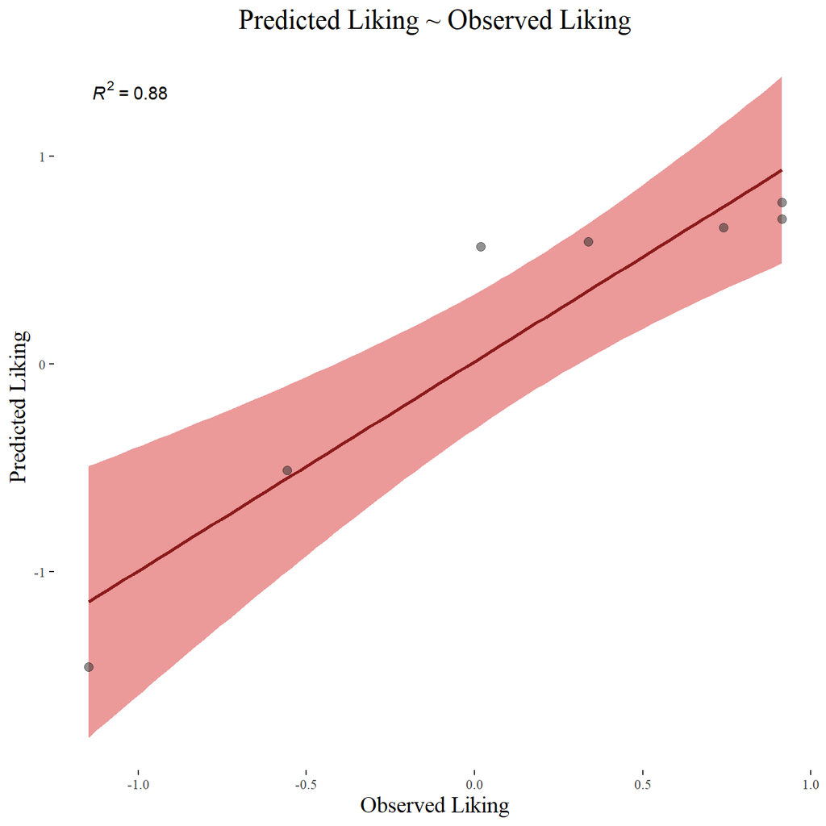

```r
# Create a scatter plot of predicted vs actual values for test data
ggplot(data.frame(Predicted = predictions,
                        Actual = boost_data[results$data_splits$test_idx,"emmean"]),
             aes(x = Actual, y = Predicted)) +
  stat_poly_line(color = "firebrick4", fill = "red3") +
  stat_poly_eq() + theme_tufte() +
  geom_point(color = "gray15", alpha = .5, shape = 20, size = 3.5) +
  labs( x="Observed Liking", y="Predicted Liking", title = "Predicted Liking ~ Observed Liking") +
  theme(plot.title =  element_text(hjust = 0.5), axis.title = element_text(size=14),title = element_text(size = 14))
```

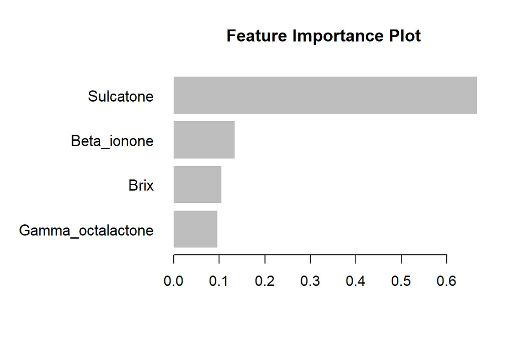

Figure 17: XGBoost variable importance

```r
xgb.plot.importance(final_model_results$importance,
                    main = "Feature Importance Plot")
```

```r
final_model_results$importance %>%
    gt() %>%
    tab_caption("XGBoost importance of features contributing to liking"
    ) %>%
    # tab_header(
    #     title = "XGBoost Feature importance",
    #     subtitle = "Features contributing to liking"
    # ) %>%
    fmt_percent(
        columns = everything(),
        decimals = 1,
        scale_values = TRUE
    )  %>%
    opt_row_striping() %>%
    tab_options(
        row_group.background.color = "gray90",
        table.border.top.width = px(3),
        table.border.bottom.width = px(3)
    )
```

Table 11: XGBoost importance of features contributing to liking

| Feature | Gain | Cover | Frequency | Importance |
| --- | --- | --- | --- | --- |
| Sulcatone | 66.6% | 35.6% | 31.9% | 66.6% |
| Beta_ionone | 13.4% | 14.5% | 14.5% | 13.4% |
| Brix | 10.5% | 20.2% | 23.8% | 10.5% |
| Gamma_octalactone | 9.6% | 29.7% | 29.8% | 9.6% |

## 9 Data Summary

The summarised volatile concentrations are reported below

Table 12: Summary of VOC concentrations (ppb) by chemical species

| Species | Chemical Class | CAS Number | MRM transition | RT | RI | LOD | LOQ | n | Mean | SD | SE | Median | Min | Max | N detected | % detected |
| --- | --- | --- | --- | --- | --- | --- | --- | --- | --- | --- | --- | --- | --- | --- | --- | --- |
| Hexanal | Aldehyde | 66-25-1 | 93.00>77.10 | 10.61 | 769 | 0.68 | 2.27 | 118 | 18.38 | 21.25 | 1.96 | 9.84 | 0.03 | 85.25 | 118 | 100.00 |
| Terpinene | Terpene | 99-86-5 | 56.00>41.10 | 11.81 | 1008 | 6.63 | 22.10 | 118 | 10.53 | 15.37 | 1.41 | 5.92 | 0.00 | 105.47 | 105 | 88.98 |
| Heptanal | Aldehyde | 111-71-7 | 93.00>91.10 | 16.55 | 882 | 0.10 | 0.33 | 118 | 32.05 | 24.52 | 2.26 | 23.41 | 0.00 | 112.15 | 117 | 99.15 |
| Methyl_hexanoate | Ester | 106-70-7 | 70.00>55.00 | 18.13 | 903 | 0.10 | 0.33 | 118 | 42.84 | 199.13 | 18.33 | 0.00 | 0.00 | 2002.82 | 49 | 41.53 |
| Limonene | Terpene | 138-86-3 | 99.00>71.20 | 18.31 | 1023 | 4.29 | 14.29 | 118 | 26.41 | 39.93 | 3.68 | 12.14 | 0.00 | 250.14 | 87 | 73.73 |
| P_cymene | Terpene | 99-87-6 | 68.00>53.20 | 17.83 | 1011 | 83.33 | 277.78 | 118 | 5.20 | 3.25 | 0.30 | 5.11 | 0.00 | 20.54 | 112 | 94.92 |
| Terpinolene | Terpene | 586-62-9 | 119.00>91.10 | 24.38 | 1080 | 0.09 | 0.30 | 118 | 20.91 | 33.87 | 3.12 | 14.73 | 0.00 | 213.29 | 94 | 79.66 |
| Octanal | Aldehyde | 124-13-0 | 58.00>56.10 | 26.60 | 981 | 0.90 | 2.99 | 118 | 7.05 | 5.93 | 0.55 | 5.22 | 0.00 | 33.49 | 117 | 99.15 |
| Sulcatone | Terpene | 110-93-0 | 67.00>65.00 | 26.84 | 958 | 0.10 | 0.33 | 118 | 62.88 | 84.21 | 7.75 | 46.03 | 0.00 | 629.09 | 117 | 99.15 |
| Methyl_octanoate | Ester | 111-11-5 | 108.00>93.10 | 31.20 | 1108 | 0.01 | 0.05 | 118 | 2.21 | 3.80 | 0.35 | 1.38 | 0.00 | 20.87 | 99 | 83.90 |
| Nonanal | Aldehyde | 124-19-6 | 87.00>55.10 | 34.65 | 1081 | 1.87 | 6.23 | 118 | 9.50 | 7.91 | 0.73 | 8.09 | 0.43 | 36.41 | 118 | 100.00 |
| Linalool_oxide | Terpene | 34995-77-2 | 93.00>77.10 | 38.32 | 1131 | 0.28 | 0.93 | 118 | 52682.49 | 108929.32 | 10027.76 | 7529.00 | 0.00 | 747850.87 | 116 | 98.31 |
| Decanal | Aldehyde | 112-31-2 | 93.00>77.10 | 39.82 | 1183 | 19.50 | 65.02 | 118 | 0.39 | 1.20 | 0.11 | 0.00 | 0.00 | 7.83 | 18 | 15.25 |
| Benzaldehyde | Aldehyde | 100-52-7 | 55.00>53.00 | 41.02 | 927 | 6.68 | 22.27 | 118 | 14.06 | 14.68 | 1.35 | 7.81 | 1.77 | 74.75 | 118 | 100.00 |
| E_2_nonal | Aldehyde | 18829-56-6 | 105.00>77.10 | 42.25 | 1133 | 1.00 | 3.33 | 118 | 0.53 | 0.88 | 0.08 | 0.00 | 0.00 | 5.13 | 43 | 36.44 |
| Linalool | Terpene | 78-70-6 | 55.00>53.00 | 42.89 | 1081 | 0.95 | 3.17 | 118 | 7313.67 | 18543.25 | 1707.04 | 682.34 | 0.00 | 112060.59 | 116 | 98.31 |
| Beta_Cyclocitral | Terpene | 432-25-7 | 121.00>93.10 | 43.91 | 1196 | 0.03 | 0.11 | 118 | 2.24 | 2.94 | 0.27 | 0.00 | 0.00 | 10.01 | 48 | 40.68 |
| Phenylacetaldehyde | Aldehyde | 122-78-1 | 109.00>67.10 | 46.61 | 1048 | 0.70 | 2.34 | 118 | 0.00 | 0.00 | 0.00 | 0.00 | 0.00 | 0.00 | 0 | 0.00 |
| Neryl_Geranyl_acetone | Terpene | 3796-70-1 | 69.00>67.00 | 55.18 | 1426 | 6.26 | 20.87 | 118 | 39.89 | 42.79 | 3.94 | 32.89 | 2.65 | 312.72 | 118 | 100.00 |
| Gamma_octalactone | Ester | 104-50-7 | 85.00>57.00 | 56.71 | 1220 | 3.13 | 10.44 | 118 | 11.38 | 13.69 | 1.26 | 6.45 | 1.17 | 63.22 | 118 | 100.00 |
| Beta_ionone | Terpene | 14901-07-6 | 177.00>147.10 | 57.10 | 1488 | 0.05 | 0.17 | 118 | 6.81 | 4.93 | 0.45 | 5.26 | 3.47 | 50.19 | 118 | 100.00 |
| BITC | Sulfur | 622-78-6 | 91.00>65.10 | 60.00 | 1318 | 2.06 | 6.85 | 118 | 4.53 | 7.13 | 0.66 | 2.62 | 0.00 | 67.27 | 91 | 77.12 |

Sugar values reported in g/100gFW; total soluble solids (brix) reported in °Brix; titratable acids reported in %CA; VOCs are reported in ppb; GTR reported in ppm.

Table 13: Variable means for 27 papaya genotypes (standard deviation)

|  | variable | 1B | Eksotika | F1_Malay | First_Lady | Holland_5 | Holland_6 | PBL1 | PBL10 | PBL11 | PBL12 | PBL13 | PBL14 | PBL15 | PBL16 | PBL21 | PBL3 | PBL4 | PBL6 | PBL7 | PBL8 | PBL9 | RB1 | Solo | Sunlight 3 | Sunlight_1 | Sunlight_2 | Tainung |
| --- | --- | --- | --- | --- | --- | --- | --- | --- | --- | --- | --- | --- | --- | --- | --- | --- | --- | --- | --- | --- | --- | --- | --- | --- | --- | --- | --- | --- |
| 1 | Glucose | 2.81 (0.41) | 2.81 (0.20) | 3.30 (0.63) | 3.36 (0.85) | 3.07 (0.93) | 2.32 (0.15) | 2.33 (0.38) | 3.54 (1.18) | 3.27 (0.71) | 3.56 (0.56) | 3.13 (0.62) | 3.10 (0.43) | 3.69 (1.56) | 3.25 (0.47) | 3.94 (0.94) | 2.66 (0.32) | 2.55 (0.47) | 2.27 (0.28) | 2.69 (0.38) | 2.30 (0.22) | 2.26 (0.37) | 3.01 (0.37) | 2.98 (0.19) | 2.27 (0.60) | 3.31 (0.97) | 3.10 (0.82) | 3.27 (0.88) |
| 2 | Fructose | 2.59 (0.43) | 2.70 (0.26) | 2.97 (0.60) | 3.06 (1.19) | 2.99 (0.55) | 2.52 (0.08) | 2.18 (0.46) | 3.74 (1.12) | 3.31 (0.73) | 3.37 (0.52) | 3.33 (0.58) | 3.29 (0.45) | 3.87 (1.68) | 3.14 (0.52) | 3.89 (0.90) | 2.39 (0.38) | 2.36 (0.38) | 2.07 (0.23) | 2.48 (0.33) | 2.16 (0.22) | 1.98 (0.38) | 2.78 (0.44) | 2.93 (0.38) | 2.03 (0.47) | 3.15 (0.96) | 3.05 (0.82) | 3.37 (0.94) |
| 3 | Sucrose | 1.71 (1.06) | 2.34 (0.43) | 4.24 (1.51) | 1.31 (0.56) | 1.09 (0.81) | 2.03 (0.96) | 3.06 (1.81) | 1.83 (1.02) | 1.13 (1.30) | 2.11 (1.14) | 0.90 (0.65) | 2.39 (0.85) | 1.05 (1.07) | 3.15 (0.31) | 3.66 (1.57) | 1.66 (0.55) | 4.74 (1.17) | 6.49 (1.80) | 6.78 (0.58) | 7.42 (1.06) | 7.03 (0.75) | 3.88 (1.69) | 1.49 (0.51) | 6.89 (1.35) | 5.61 (2.13) | 5.19 (1.59) | 1.32 (0.76) |
| 4 | total_sugar | 7.12 (1.10) | 7.86 (0.63) | 10.51 (0.92) | 7.73 (1.69) | 7.15 (1.74) | 6.88 (1.12) | 7.57 (2.38) | 9.11 (1.46) | 7.70 (1.58) | 9.04 (1.14) | 7.37 (0.87) | 8.78 (0.21) | 8.61 (2.73) | 9.54 (0.78) | 11.49 (0.69) | 6.70 (0.72) | 9.66 (0.66) | 10.83 (1.81) | 11.96 (1.21) | 11.88 (0.68) | 11.26 (1.35) | 9.67 (1.37) | 7.40 (1.03) | 11.20 (2.28) | 12.08 (0.48) | 11.34 (0.37) | 7.95 (1.55) |
| 5 | Glucose_prop | 0.40 (0.05) | 0.36 (0.02) | 0.32 (0.07) | 0.43 (0.02) | 0.43 (0.06) | 0.34 (0.04) | 0.33 (0.10) | 0.38 (0.07) | 0.43 (0.07) | 0.39 (0.05) | 0.42 (0.05) | 0.35 (0.05) | 0.41 (0.08) | 0.34 (0.03) | 0.34 (0.07) | 0.40 (0.03) | 0.27 (0.05) | 0.21 (0.04) | 0.22 (0.01) | 0.20 (0.03) | 0.20 (0.01) | 0.32 (0.06) | 0.41 (0.04) | 0.20 (0.02) | 0.28 (0.08) | 0.27 (0.07) | 0.41 (0.04) |
| 6 | Fructose_prop | 0.37 (0.07) | 0.34 (0.02) | 0.28 (0.06) | 0.39 (0.06) | 0.43 (0.05) | 0.37 (0.06) | 0.30 (0.07) | 0.40 (0.06) | 0.43 (0.07) | 0.38 (0.06) | 0.45 (0.04) | 0.37 (0.05) | 0.43 (0.08) | 0.33 (0.03) | 0.34 (0.07) | 0.36 (0.04) | 0.25 (0.05) | 0.19 (0.03) | 0.21 (0.01) | 0.18 (0.03) | 0.17 (0.02) | 0.29 (0.07) | 0.40 (0.01) | 0.18 (0.01) | 0.26 (0.08) | 0.27 (0.07) | 0.42 (0.05) |
| 7 | Sucrose_prop | 0.23 (0.13) | 0.30 (0.04) | 0.40 (0.13) | 0.18 (0.08) | 0.15 (0.09) | 0.29 (0.10) | 0.37 (0.17) | 0.22 (0.14) | 0.14 (0.15) | 0.23 (0.11) | 0.13 (0.09) | 0.27 (0.09) | 0.15 (0.16) | 0.33 (0.06) | 0.32 (0.14) | 0.25 (0.07) | 0.49 (0.10) | 0.59 (0.07) | 0.57 (0.02) | 0.62 (0.06) | 0.63 (0.03) | 0.39 (0.13) | 0.20 (0.04) | 0.62 (0.04) | 0.46 (0.17) | 0.46 (0.14) | 0.17 (0.09) |
| 8 | wet_fraction | 0.90 (0.01) | 0.89 (0.01) | 0.87 (0.01) | 0.89 (0.02) | 0.89 (0.02) | 0.89 (0.02) | 0.89 (0.02) | 0.86 (0.01) | 0.88 (0.01) | 0.87 (0.01) | 0.89 (0.00) | 0.87 (0.01) | 0.88 (0.04) | 0.87 (0.01) | 0.85 (0.01) | 0.90 (0.01) | 0.87 (0.00) | 0.86 (0.01) | 0.86 (0.01) | 0.85 (0.00) | 0.86 (0.01) | 0.87 (0.01) | 0.88 (0.02) | 0.86 (0.01) | 0.85 (0.01) | 0.85 (0.01) | 0.89 (0.01) |
| 9 | GTR_conc | 0.42 (0.32) | 0.97 (0.40) | 0.62 (0.46) | 1.07 (0.85) | 0.59 (0.69) | 0.08 (0.01) | 0.02 (0.03) | 0.22 (0.11) | 0.55 (0.37) | 1.74 (1.46) | 1.28 (1.62) | 0.62 (0.17) | 3.48 (4.94) | 0.07 (0.05) | 0.03 (0.03) | 0.03 (0.02) | 0.10 (0.05) | 0.62 (0.65) | 0.53 (0.68) | 0.02 (0.03) | 0.39 (0.66) | 0.86 (1.56) | 2.41 (3.03) | 0.15 (0.14) | 0.89 (0.65) | 0.84 (0.74) | 1.41 (1.72) |
| 10 | pH | 5.50 (0.54) | 5.25 (0.13) | 5.30 (0.14) | 5.47 (0.17) | 5.56 (0.35) | 5.77 (0.49) | 5.55 (0.21) | 5.38 (0.22) | 5.42 (0.28) | 5.45 (0.13) | 5.47 (0.12) | 5.35 (0.10) | 5.42 (0.24) | 5.55 (0.13) | 5.42 (0.10) | 5.60 (0.00) | 5.67 (0.05) | 5.57 (0.05) | 5.60 (0.08) | 5.62 (0.05) | 5.55 (0.06) | 5.52 (0.24) | 5.66 (0.19) | 5.55 (0.06) | 5.62 (0.10) | 5.67 (0.13) | 5.33 (0.15) |

[output cut: 44 more lines]

## 10 General information

This document was last updated at 2026-01-03 10:57:32.827994 using R Markdown (built with R version 4.4.2 (2024-10-31 ucrt)). The source code for this website can be found on https://github.com/JoshLomax/Papaya_sensory_metabolomics.

## Bibliography

Brewer S, Plotto A, Bai J, et al. (2021) Evaluation of 21 papaya (*Carica papaya* L.) accessions in southern Florida for fruit quality, aroma, plant height, and yield components. Scientia Horticulturae 288:110387. doi: 10.1016/j.scienta.2021.110387

Colantonio V, Ferrão LFV, Tieman DM, et al. (2022) Metabolomic selection for enhanced fruit flavor. Proc Natl Acad Sci 119:e2115865119. doi: 10.1073/pnas.2115865119

Frey BJ, Dueck D (2007) Clustering by passing messages between data points. Science 315:972–976. doi: 10.1126/science.1136800

Friedman JH (2001) Greedy function approximation: A gradient boosting machine. Ann Stat 29:1189–1232. doi: 10.1214/aos/1013203451

Lomax J, Ford R, Bar I (2024) Multi-omic applications for understanding and enhancing tropical fruit flavour. Plant Mol Biol 114:83. doi: 10.1007/s11103-024-01480-7

Meuwissen THE, Hayes BJ, Goddard ME (2001) Prediction of total genetic value using genome-wide dense marker maps. Genetics 157:1819–1829. doi: 10.1093/genetics/157.4.1819

Pico J, Gerbrandt EM, Castellarin SD (2022) Optimization and validation of a SPME-GC/MS method for the determination of volatile compounds, including enantiomeric analysis, in northern highbush blueberries (*Vaccinium corymbosum L.*). Food Chem 368:130812. doi: 10.1016/j.foodchem.2021.130812

Zhou Z, Bar I, Ford R, et al. (2022) Biochemical, Sensory, and Molecular Evaluation of Flavour and Consumer Acceptability in Australian Papaya (*Carica papaya* L.) Varieties. International Journal of Molecular Sciences 23:6313. doi: 10.3390/ijms23116313

Zhou Z, Ford R, Bar I, Kanchana-udomkan C (2021) Papaya (*Carica papaya* L.) Flavour Profiling. Genes 12:1416. doi: 10.3390/genes12091416